# How chooseGCM selection changes with increasing area?

This Rmarkdown is part of the following article:

Esser, L.F., Bailly, D., Lima, M.R., Ré, R. 2024. chooseGCM: a toolkit to select General Circulation Models in R. *In prep*.

## Introduction

chooseGCM is a solution for GCMs selection in Climate Change research. We built this Rmarkdown as a way to test the properties of the methods underlying chooseGCM. Results from each function will be presented side by side with changing variables, allowing better comparison. Here, we have already downloaded GCMs data.

This Rmarkdown will apply different algorithms implemented in chooseGCM in an increasing area. The aim is to understand from which point the GCM selection starts to change. For that, we will use *Araucaria angustifolia* records and will create a buffer from increassing size.

```r
# Install and open CRAN libraries
for(x in c("devtools", "geodata", "terra", "tictoc") ){
  if (!require(x, character.only = TRUE)) {
      install.packages(x, dependencies = TRUE)
      library(x, character.only = TRUE)
  }
}

# Install and open chooseGCM
if (!require("chooseGCM", character.only = TRUE)) {
    devtools::install_github("luizesser/chooseGCM")
    library("chooseGCM", character.only = TRUE)
}

# Install and open caretSDM
if (!require("caretSDM", character.only = TRUE)) {
    devtools::install_github("luizesser/caretSDM")
    library("caretSDM", character.only = TRUE)
}
```

## Preparing data

### Download GCMs

To obtain GCMs data, we recommend using `geodata` package, which links directly to the WorldClim 2.1 database. We have previously downloaded GCMs data, but an example code is supplied below.

```r
gcms <- geodata:::.cmods
for (r in c(10)) {
  for ( g in gcms ) {
    geodata::cmip6_world(model = g,
                         ssp = "585",
                         time = "2081-2100",
                         var = "bioc",
                         res = r,
                         path = ""
    )
  }
}
```

### Import GCMs

The function `import_gcms` helps the user to import data in the correct way, which is a list of GCMs. Each element of the list is a `SpatRaster` from `terra` package, containing all variables. The list should be named with GCMs names to better plot results.

```r
tictoc::tic()
s10 <- chooseGCM::import_gcms(path = "~/storage/WC_data/WC_data_all_gcms_10/",
                              gcm_names = c("ACCESS-CM2","ACCESS-ESM1-5",
                                            "CanESM5-CanOE","CMCC-ESM2",
                                            "CNRM-CM6-1-HR","CNRM-CM6-1",
                                            "CNRM-ESM2-1","EC-Earth3-Veg",
                                            "EC-Earth3-Veg-LR","FIO-ESM-2-0",
                                            "GISS-E2-1-G","GISS-E2-1-H",
                                            "HadGEM3-GC31-LL","INM-CM5-0",
                                            "INM-CM4-8","IPSL-CM6A-LR",
                                            "MIROC-ES2L","MIROC6",
                                            "MPI-ESM1-2-LR","MPI-ESM1-2-HR",
                                            "MRI-ESM2-0","UKESM1-0-LL"))
tictoc::toc()
```

```
## 0.366 sec elapsed
```

## Species Data

```r
occ_data <- geodata::sp_occurrence("Araucaria", "angustifolia")
```

```
## 1932 records found
```

```
## 0-300-600-900-1200-1500-1800-1932
## 1932 records downloaded
```

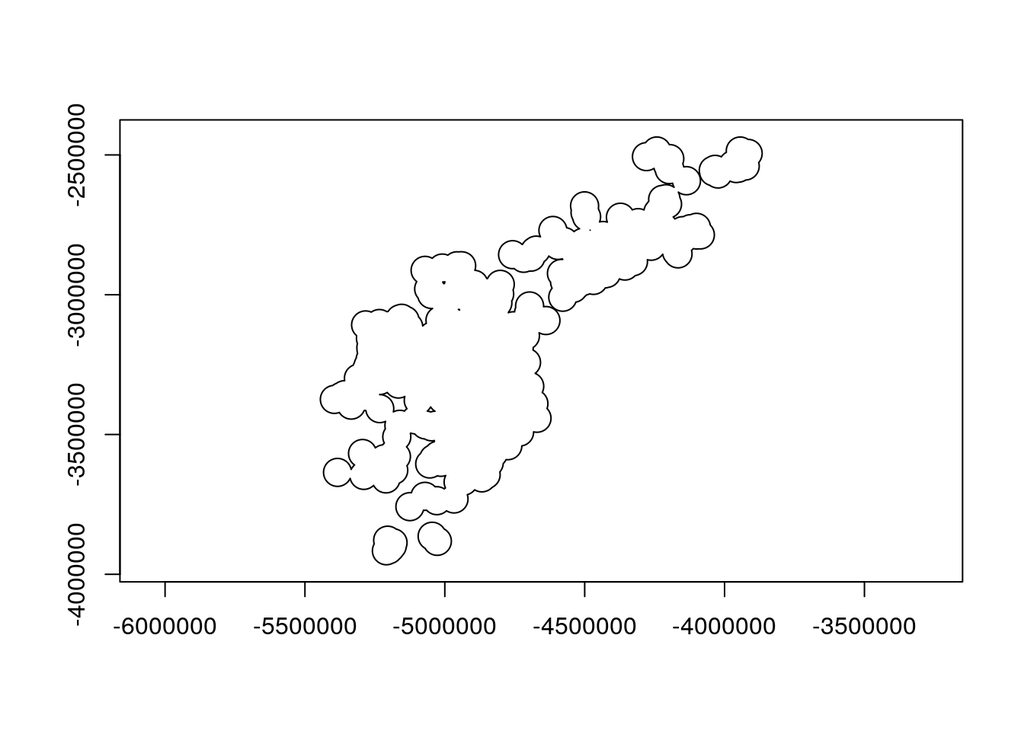

```r
occ_data <- occ_data |>
  dplyr::filter(lon >= -64) |>
  dplyr::filter(lon <= -33) |>
  dplyr::filter(lat <= -19.5) |>
  dplyr::filter(lat >= -33)

buffer50 <- na.omit(occ_data[,c("lon", "lat")]) |>
  sf::st_as_sf(coords= c(1,2), crs = 4326) |>
  sf::st_transform(crs=sf::st_crs(6933)) |>
  sf::st_buffer(dist = 50000) |>
  sf::st_union()
buffer100 <- na.omit(occ_data[,c("lon", "lat")]) |>
  sf::st_as_sf(coords= c(1,2), crs = 4326) |>
  sf::st_transform(crs=sf::st_crs(6933)) |>
  sf::st_buffer(dist = 100000) |>
  sf::st_union()
buffer150 <- na.omit(occ_data[,c("lon", "lat")]) |>
  sf::st_as_sf(coords= c(1,2), crs = 4326) |>
  sf::st_transform(crs=sf::st_crs(6933)) |>
  sf::st_buffer(dist = 150000) |>
  sf::st_union()
buffer200 <- na.omit(occ_data[,c("lon", "lat")]) |>
  sf::st_as_sf(coords= c(1,2), crs = 4326) |>
  sf::st_transform(crs=sf::st_crs(6933)) |>
  sf::st_buffer(dist = 200000) |>
  sf::st_union()
buffer250 <- na.omit(occ_data[,c("lon", "lat")]) |>
  sf::st_as_sf(coords= c(1,2), crs = 4326) |>
  sf::st_transform(crs=sf::st_crs(6933)) |>
  sf::st_buffer(dist = 250000) |>
  sf::st_union()
buffer300 <- na.omit(occ_data[,c("lon", "lat")]) |>
  sf::st_as_sf(coords= c(1,2), crs = 4326) |>
  sf::st_transform(crs=sf::st_crs(6933)) |>
  sf::st_buffer(dist = 300000) |>
  sf::st_union()
buffer350 <- na.omit(occ_data[,c("lon", "lat")]) |>
  sf::st_as_sf(coords= c(1,2), crs = 4326) |>
  sf::st_transform(crs=sf::st_crs(6933)) |>
  sf::st_buffer(dist = 350000) |>
  sf::st_union()
buffer400 <- na.omit(occ_data[,c("lon", "lat")]) |>
  sf::st_as_sf(coords= c(1,2), crs = 4326) |>
  sf::st_transform(crs=sf::st_crs(6933)) |>
  sf::st_buffer(dist = 400000) |>
  sf::st_union()
buffer450 <- na.omit(occ_data[,c("lon", "lat")]) |>
  sf::st_as_sf(coords= c(1,2), crs = 4326) |>
  sf::st_transform(crs=sf::st_crs(6933)) |>
  sf::st_buffer(dist = 450000) |>
  sf::st_union()
buffer500 <- na.omit(occ_data[,c("lon", "lat")]) |>
  sf::st_as_sf(coords= c(1,2), crs = 4326) |>
  sf::st_transform(crs=sf::st_crs(6933)) |>
  sf::st_buffer(dist = 500000) |>
  sf::st_union()
plot(buffer50, axes=T)
```

## Applying algorithms

First we will set a seed to standardize randomic outputs.

```r
set.seed(1)
```

Now we will perform the Monte Carlo analysis to each type of algorithm and to different sets of variables.

### Hierarchical Clustering selection

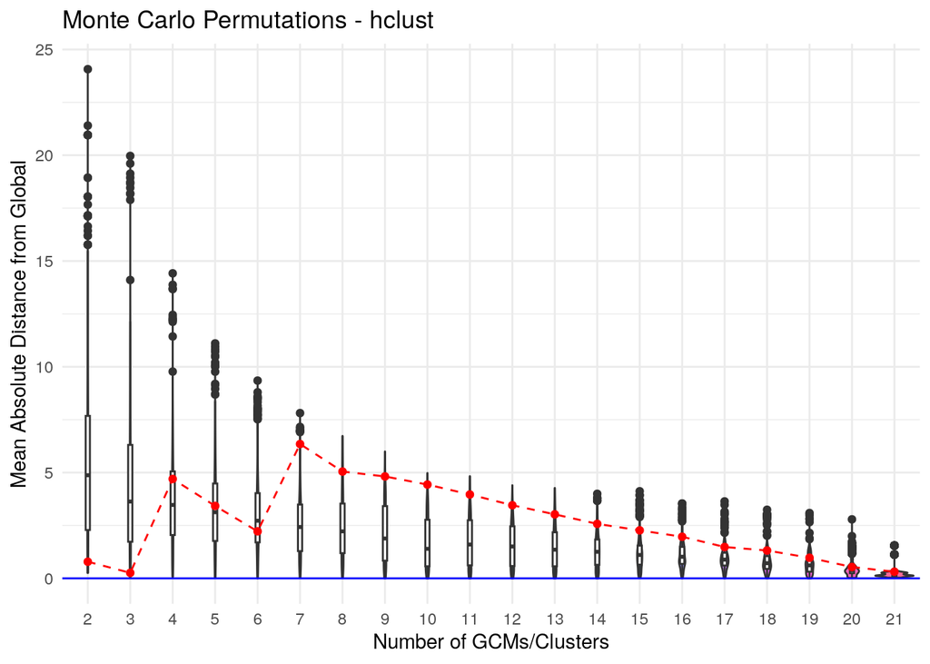

```
##
## $suggested_gcms
## $suggested_gcms$k2
## [1] "CMCC-ESM2"     "MPI-ESM1-2-LR"
##
## $suggested_gcms$k3
## [1] "CMCC-ESM2"     "IPSL-CM6A-LR"  "MPI-ESM1-2-LR"
##
## $suggested_gcms$k4
## [1] "CMCC-ESM2"     "IPSL-CM6A-LR"  "MPI-ESM1-2-LR" "MPI-ESM1-2-HR"
##
## $suggested_gcms$k5
## [1] "CMCC-ESM2"     "IPSL-CM6A-LR"  "MPI-ESM1-2-LR" "FIO-ESM-2-0"
## [5] "MPI-ESM1-2-HR"
##
## $suggested_gcms$k6
## [1] "CMCC-ESM2"       "HadGEM3-GC31-LL" "IPSL-CM6A-LR"    "MPI-ESM1-2-LR"
## [5] "FIO-ESM-2-0"     "MPI-ESM1-2-HR"
##
## $suggested_gcms$k7
## [1] "CMCC-ESM2"       "HadGEM3-GC31-LL" "CanESM5-CanOE"   "MPI-ESM1-2-LR"
## [5] "FIO-ESM-2-0"     "IPSL-CM6A-LR"    "MPI-ESM1-2-HR"
##
## $suggested_gcms$k8
## [1] "CMCC-ESM2"       "HadGEM3-GC31-LL" "CanESM5-CanOE"   "MPI-ESM1-2-LR"
## [5] "CNRM-ESM2-1"     "FIO-ESM-2-0"     "IPSL-CM6A-LR"    "MPI-ESM1-2-HR"
##
## $suggested_gcms$k9
## [1] "CMCC-ESM2"       "HadGEM3-GC31-LL" "CanESM5-CanOE"   "MPI-ESM1-2-LR"
## [5] "CNRM-ESM2-1"     "FIO-ESM-2-0"     "GISS-E2-1-H"     "IPSL-CM6A-LR"
## [9] "MPI-ESM1-2-HR"
##
## $suggested_gcms$k10
##  [1] "ACCESS-CM2"      "HadGEM3-GC31-LL" "CanESM5-CanOE"   "CMCC-ESM2"
##  [5] "MPI-ESM1-2-LR"   "CNRM-ESM2-1"     "FIO-ESM-2-0"     "GISS-E2-1-H"
##  [9] "IPSL-CM6A-LR"    "MPI-ESM1-2-HR"
##
## $suggested_gcms$k11
##  [1] "ACCESS-CM2"      "HadGEM3-GC31-LL" "CanESM5-CanOE"   "CMCC-ESM2"
##  [5] "CNRM-CM6-1"      "CNRM-ESM2-1"     "FIO-ESM-2-0"     "GISS-E2-1-H"
```

[output cut: 51 more lines]

```
##
## $suggested_gcms$k20
##  [1] "ACCESS-CM2"       "ACCESS-ESM1-5"    "CanESM5-CanOE"    "CMCC-ESM2"
##  [5] "CNRM-CM6-1"       "CNRM-ESM2-1"      "EC-Earth3-Veg"    "EC-Earth3-Veg-LR"
##  [9] "FIO-ESM-2-0"      "GISS-E2-1-G"      "GISS-E2-1-H"      "HadGEM3-GC31-LL"
## [13] "INM-CM4-8"        "INM-CM5-0"        "IPSL-CM6A-LR"     "MIROC-ES2L"
## [17] "MIROC6"           "MPI-ESM1-2-HR"    "MPI-ESM1-2-LR"    "MRI-ESM2-0"
##
## $suggested_gcms$k21
##  [1] "ACCESS-CM2"       "ACCESS-ESM1-5"    "CanESM5-CanOE"    "CMCC-ESM2"
##  [5] "CNRM-CM6-1"       "CNRM-ESM2-1"      "EC-Earth3-Veg"    "EC-Earth3-Veg-LR"
##  [9] "FIO-ESM-2-0"      "GISS-E2-1-G"      "GISS-E2-1-H"      "HadGEM3-GC31-LL"
## [13] "INM-CM4-8"        "INM-CM5-0"        "IPSL-CM6A-LR"     "MIROC-ES2L"
## [17] "MIROC6"           "MPI-ESM1-2-HR"    "MPI-ESM1-2-LR"    "MRI-ESM2-0"
## [21] "UKESM1-0-LL"
```

```r
tictoc::tic("Hierarchical Clustering 50")
mc_hclust_50 <- montecarlo_gcms(s10,
                             var_names = c("bio1", "bio12"),
                             study_area = buffer50,
                             scale = TRUE,
                             perm = 10000,
                             dist_method = "euclidean",
                             clustering_method = "hclust")
mc_hclust_50
```

```r
hclust_50 <- mc_hclust_50$suggested_gcms$k3
tictoc::toc()
```

```
## Hierarchical Clustering 50: 12.179 sec elapsed
```

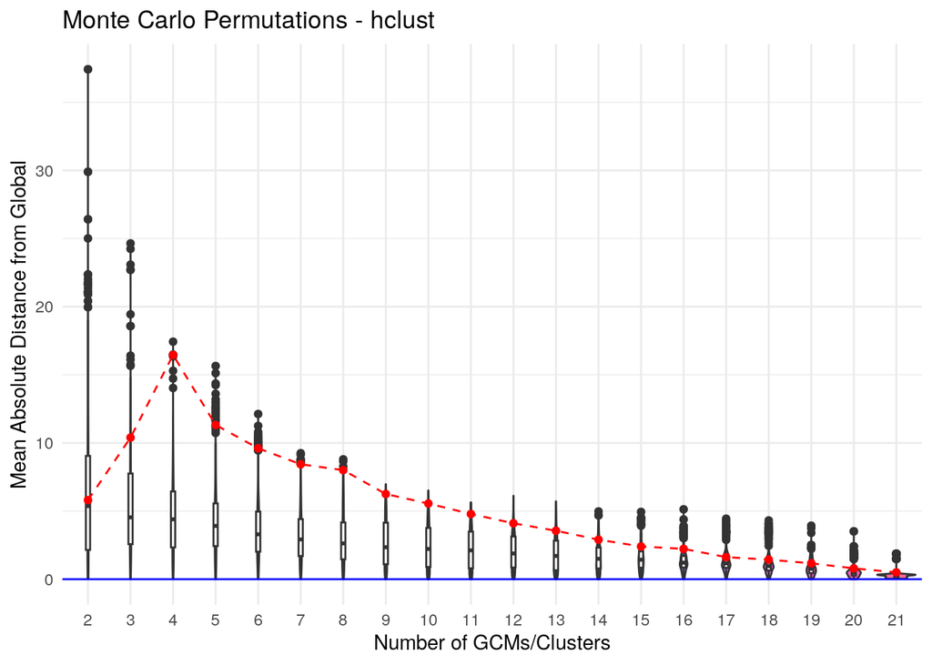

```
##
## $suggested_gcms
## $suggested_gcms$k2
## [1] "MRI-ESM2-0"    "CNRM-CM6-1-HR"
##
## $suggested_gcms$k3
## [1] "MRI-ESM2-0"    "CNRM-CM6-1-HR" "CanESM5-CanOE"
##
## $suggested_gcms$k4
## [1] "MRI-ESM2-0"    "CNRM-CM6-1-HR" "CanESM5-CanOE" "MPI-ESM1-2-HR"
##
## $suggested_gcms$k5
## [1] "MRI-ESM2-0"    "UKESM1-0-LL"   "CanESM5-CanOE" "CNRM-CM6-1-HR"
## [5] "MPI-ESM1-2-HR"
##
## $suggested_gcms$k6
## [1] "MRI-ESM2-0"    "UKESM1-0-LL"   "CanESM5-CanOE" "CNRM-CM6-1-HR"
## [5] "GISS-E2-1-H"   "MPI-ESM1-2-HR"
##
## $suggested_gcms$k7
## [1] "MRI-ESM2-0"    "UKESM1-0-LL"   "CanESM5-CanOE" "CNRM-CM6-1-HR"
## [5] "GISS-E2-1-H"   "IPSL-CM6A-LR"  "MPI-ESM1-2-HR"
##
## $suggested_gcms$k8
## [1] "ACCESS-CM2"    "UKESM1-0-LL"   "CanESM5-CanOE" "CNRM-CM6-1-HR"
## [5] "MRI-ESM2-0"    "GISS-E2-1-H"   "IPSL-CM6A-LR"  "MPI-ESM1-2-HR"
##
## $suggested_gcms$k9
## [1] "ACCESS-CM2"    "UKESM1-0-LL"   "CanESM5-CanOE" "CNRM-CM6-1-HR"
## [5] "MRI-ESM2-0"    "GISS-E2-1-H"   "IPSL-CM6A-LR"  "MPI-ESM1-2-LR"
## [9] "MPI-ESM1-2-HR"
##
## $suggested_gcms$k10
##  [1] "ACCESS-CM2"    "UKESM1-0-LL"   "CanESM5-CanOE" "CMCC-ESM2"
##  [5] "CNRM-CM6-1-HR" "MRI-ESM2-0"    "GISS-E2-1-H"   "IPSL-CM6A-LR"
##  [9] "MPI-ESM1-2-LR" "MPI-ESM1-2-HR"
##
## $suggested_gcms$k11
##  [1] "ACCESS-CM2"       "UKESM1-0-LL"      "CanESM5-CanOE"    "CMCC-ESM2"
##  [5] "EC-Earth3-Veg-LR" "CNRM-CM6-1-HR"    "MRI-ESM2-0"       "GISS-E2-1-H"
```

[output cut: 51 more lines]

```
##
## $suggested_gcms$k20
##  [1] "ACCESS-CM2"       "ACCESS-ESM1-5"    "CanESM5-CanOE"    "CMCC-ESM2"
##  [5] "CNRM-CM6-1"       "CNRM-CM6-1-HR"    "EC-Earth3-Veg"    "EC-Earth3-Veg-LR"
##  [9] "FIO-ESM-2-0"      "GISS-E2-1-G"      "GISS-E2-1-H"      "UKESM1-0-LL"
## [13] "INM-CM4-8"        "INM-CM5-0"        "IPSL-CM6A-LR"     "MIROC-ES2L"
## [17] "MIROC6"           "MPI-ESM1-2-HR"    "MPI-ESM1-2-LR"    "MRI-ESM2-0"
##
## $suggested_gcms$k21
##  [1] "ACCESS-CM2"       "ACCESS-ESM1-5"    "CanESM5-CanOE"    "CMCC-ESM2"
##  [5] "CNRM-CM6-1"       "CNRM-CM6-1-HR"    "EC-Earth3-Veg"    "EC-Earth3-Veg-LR"
##  [9] "FIO-ESM-2-0"      "GISS-E2-1-G"      "GISS-E2-1-H"      "HadGEM3-GC31-LL"
## [13] "INM-CM4-8"        "INM-CM5-0"        "IPSL-CM6A-LR"     "MIROC-ES2L"
## [17] "MIROC6"           "MPI-ESM1-2-HR"    "MPI-ESM1-2-LR"    "MRI-ESM2-0"
## [21] "UKESM1-0-LL"
```

```r
tictoc::tic("Hierarchical Clustering 100")
mc_hclust_100 <- montecarlo_gcms(s10,
                             var_names = c("bio1", "bio12"),
                             study_area = buffer100,
                             scale = TRUE,
                             perm = 10000,
                             dist_method = "euclidean",
                             clustering_method = "hclust")
mc_hclust_100
```

```r
hclust_100 <- mc_hclust_100$suggested_gcms$k3
tictoc::toc()
```

```
## Hierarchical Clustering 100: 12.606 sec elapsed
```

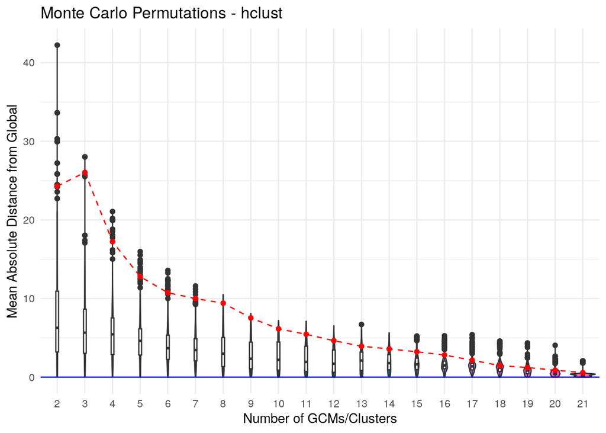

```
##
## $suggested_gcms
## $suggested_gcms$k2
## [1] "MIROC6"        "CanESM5-CanOE"
##
## $suggested_gcms$k3
## [1] "MIROC6"        "CanESM5-CanOE" "MPI-ESM1-2-HR"
##
## $suggested_gcms$k4
## [1] "UKESM1-0-LL"   "CanESM5-CanOE" "MIROC6"        "MPI-ESM1-2-HR"
##
## $suggested_gcms$k5
## [1] "UKESM1-0-LL"   "CanESM5-CanOE" "CNRM-CM6-1-HR" "MIROC6"
## [5] "MPI-ESM1-2-HR"
##
## $suggested_gcms$k6
## [1] "ACCESS-CM2"    "UKESM1-0-LL"   "CanESM5-CanOE" "CNRM-CM6-1-HR"
## [5] "MIROC6"        "MPI-ESM1-2-HR"
##
## $suggested_gcms$k7
## [1] "ACCESS-CM2"    "UKESM1-0-LL"   "CanESM5-CanOE" "CNRM-CM6-1-HR"
## [5] "GISS-E2-1-H"   "MIROC6"        "MPI-ESM1-2-HR"
##
## $suggested_gcms$k8
## [1] "ACCESS-CM2"    "UKESM1-0-LL"   "CanESM5-CanOE" "CNRM-CM6-1-HR"
## [5] "GISS-E2-1-H"   "MIROC6"        "IPSL-CM6A-LR"  "MPI-ESM1-2-HR"
##
## $suggested_gcms$k9
## [1] "ACCESS-CM2"    "UKESM1-0-LL"   "CanESM5-CanOE" "CNRM-CM6-1-HR"
## [5] "GISS-E2-1-H"   "MIROC6"        "IPSL-CM6A-LR"  "MIROC-ES2L"
## [9] "MPI-ESM1-2-HR"
##
## $suggested_gcms$k10
##  [1] "ACCESS-CM2"    "UKESM1-0-LL"   "CanESM5-CanOE" "EC-Earth3-Veg"
##  [5] "CNRM-CM6-1-HR" "GISS-E2-1-H"   "MIROC6"        "IPSL-CM6A-LR"
##  [9] "MIROC-ES2L"    "MPI-ESM1-2-HR"
##
## $suggested_gcms$k11
##  [1] "ACCESS-CM2"    "UKESM1-0-LL"   "CanESM5-CanOE" "CMCC-ESM2"
##  [5] "EC-Earth3-Veg" "CNRM-CM6-1-HR" "GISS-E2-1-H"   "MIROC6"
```

[output cut: 51 more lines]

```
##
## $suggested_gcms$k20
##  [1] "ACCESS-CM2"       "UKESM1-0-LL"      "CanESM5-CanOE"    "CMCC-ESM2"
##  [5] "CNRM-CM6-1"       "CNRM-CM6-1-HR"    "EC-Earth3-Veg"    "EC-Earth3-Veg-LR"
##  [9] "FIO-ESM-2-0"      "GISS-E2-1-G"      "GISS-E2-1-H"      "HadGEM3-GC31-LL"
## [13] "INM-CM4-8"        "INM-CM5-0"        "IPSL-CM6A-LR"     "MIROC-ES2L"
## [17] "MIROC6"           "MPI-ESM1-2-HR"    "MPI-ESM1-2-LR"    "MRI-ESM2-0"
##
## $suggested_gcms$k21
##  [1] "ACCESS-CM2"       "ACCESS-ESM1-5"    "CanESM5-CanOE"    "CMCC-ESM2"
##  [5] "CNRM-CM6-1"       "CNRM-CM6-1-HR"    "EC-Earth3-Veg"    "EC-Earth3-Veg-LR"
##  [9] "FIO-ESM-2-0"      "GISS-E2-1-G"      "GISS-E2-1-H"      "HadGEM3-GC31-LL"
## [13] "INM-CM4-8"        "INM-CM5-0"        "IPSL-CM6A-LR"     "MIROC-ES2L"
## [17] "MIROC6"           "MPI-ESM1-2-HR"    "MPI-ESM1-2-LR"    "MRI-ESM2-0"
## [21] "UKESM1-0-LL"
```

```r
tictoc::tic("Hierarchical Clustering 150")
mc_hclust_150 <- montecarlo_gcms(s10,
                             var_names = c("bio1", "bio12"),
                             study_area = buffer150,
                             scale = TRUE,
                             perm = 10000,
                             dist_method = "euclidean",
                             clustering_method = "hclust")
mc_hclust_150
```

```r
hclust_150 <- mc_hclust_150$suggested_gcms$k3
tictoc::toc()
```

```
## Hierarchical Clustering 150: 11.605 sec elapsed
```

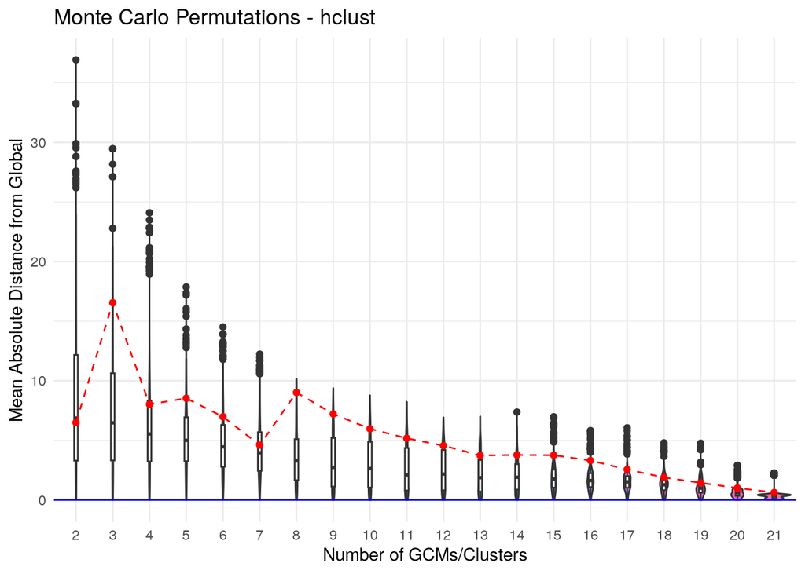

```
##
## $suggested_gcms
## $suggested_gcms$k2
## [1] "CNRM-CM6-1"   "IPSL-CM6A-LR"
##
## $suggested_gcms$k3
## [1] "CNRM-CM6-1"    "IPSL-CM6A-LR"  "MPI-ESM1-2-HR"
##
## $suggested_gcms$k4
## [1] "MPI-ESM1-2-LR" "IPSL-CM6A-LR"  "CNRM-CM6-1"    "MPI-ESM1-2-HR"
##
## $suggested_gcms$k5
## [1] "MPI-ESM1-2-LR" "IPSL-CM6A-LR"  "CNRM-CM6-1"    "GISS-E2-1-G"
## [5] "MPI-ESM1-2-HR"
##
## $suggested_gcms$k6
## [1] "FIO-ESM-2-0"   "MPI-ESM1-2-LR" "IPSL-CM6A-LR"  "CNRM-CM6-1"
## [5] "GISS-E2-1-G"   "MPI-ESM1-2-HR"
##
## $suggested_gcms$k7
## [1] "FIO-ESM-2-0"   "UKESM1-0-LL"   "IPSL-CM6A-LR"  "CNRM-CM6-1"
## [5] "GISS-E2-1-G"   "MPI-ESM1-2-LR" "MPI-ESM1-2-HR"
##
## $suggested_gcms$k8
## [1] "FIO-ESM-2-0"   "UKESM1-0-LL"   "CanESM5-CanOE" "CNRM-CM6-1"
## [5] "GISS-E2-1-G"   "MPI-ESM1-2-LR" "IPSL-CM6A-LR"  "MPI-ESM1-2-HR"
##
## $suggested_gcms$k9
## [1] "FIO-ESM-2-0"   "UKESM1-0-LL"   "CanESM5-CanOE" "CNRM-CM6-1"
## [5] "GISS-E2-1-G"   "MRI-ESM2-0"    "IPSL-CM6A-LR"  "MPI-ESM1-2-LR"
## [9] "MPI-ESM1-2-HR"
##
## $suggested_gcms$k10
##  [1] "FIO-ESM-2-0"   "UKESM1-0-LL"   "CanESM5-CanOE" "CNRM-CM6-1"
##  [5] "CNRM-CM6-1-HR" "GISS-E2-1-G"   "MRI-ESM2-0"    "IPSL-CM6A-LR"
##  [9] "MPI-ESM1-2-LR" "MPI-ESM1-2-HR"
##
## $suggested_gcms$k11
##  [1] "FIO-ESM-2-0"   "UKESM1-0-LL"   "CanESM5-CanOE" "CMCC-ESM2"
##  [5] "CNRM-CM6-1"    "CNRM-CM6-1-HR" "GISS-E2-1-G"   "MRI-ESM2-0"
```

[output cut: 51 more lines]

```
##
## $suggested_gcms$k20
##  [1] "ACCESS-CM2"       "UKESM1-0-LL"      "CanESM5-CanOE"    "CMCC-ESM2"
##  [5] "CNRM-CM6-1"       "CNRM-CM6-1-HR"    "EC-Earth3-Veg"    "EC-Earth3-Veg-LR"
##  [9] "FIO-ESM-2-0"      "GISS-E2-1-G"      "GISS-E2-1-H"      "HadGEM3-GC31-LL"
## [13] "INM-CM4-8"        "INM-CM5-0"        "IPSL-CM6A-LR"     "MIROC-ES2L"
## [17] "MIROC6"           "MPI-ESM1-2-HR"    "MPI-ESM1-2-LR"    "MRI-ESM2-0"
##
## $suggested_gcms$k21
##  [1] "ACCESS-CM2"       "ACCESS-ESM1-5"    "CanESM5-CanOE"    "CMCC-ESM2"
##  [5] "CNRM-CM6-1"       "CNRM-CM6-1-HR"    "EC-Earth3-Veg"    "EC-Earth3-Veg-LR"
##  [9] "FIO-ESM-2-0"      "GISS-E2-1-G"      "GISS-E2-1-H"      "HadGEM3-GC31-LL"
## [13] "INM-CM4-8"        "INM-CM5-0"        "IPSL-CM6A-LR"     "MIROC-ES2L"
## [17] "MIROC6"           "MPI-ESM1-2-HR"    "MPI-ESM1-2-LR"    "MRI-ESM2-0"
## [21] "UKESM1-0-LL"
```

```r
tictoc::tic("Hierarchical Clustering 200")
mc_hclust_200 <- montecarlo_gcms(s10,
                             var_names = c("bio1", "bio12"),
                             study_area = buffer200,
                             scale = TRUE,
                             perm = 10000,
                             dist_method = "euclidean",
                             clustering_method = "hclust")
mc_hclust_200
```

```r
hclust_200 <- mc_hclust_200$suggested_gcms$k3
tictoc::toc()
```

```
## Hierarchical Clustering 200: 12.561 sec elapsed
```

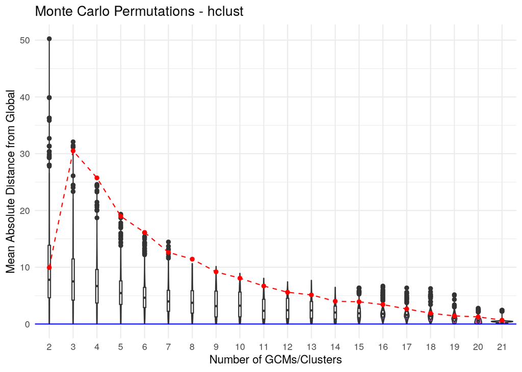

```
##
## $suggested_gcms
## $suggested_gcms$k2
## [1] "CNRM-CM6-1"    "CanESM5-CanOE"
##
## $suggested_gcms$k3
## [1] "CNRM-CM6-1"    "CanESM5-CanOE" "MPI-ESM1-2-HR"
##
## $suggested_gcms$k4
## [1] "ACCESS-CM2"    "CNRM-CM6-1"    "CanESM5-CanOE" "MPI-ESM1-2-HR"
##
## $suggested_gcms$k5
## [1] "ACCESS-CM2"    "MIROC-ES2L"    "CanESM5-CanOE" "CNRM-CM6-1"
## [5] "MPI-ESM1-2-HR"
##
## $suggested_gcms$k6
## [1] "ACCESS-CM2"    "MIROC-ES2L"    "CanESM5-CanOE" "CNRM-CM6-1"
## [5] "GISS-E2-1-G"   "MPI-ESM1-2-HR"
##
## $suggested_gcms$k7
## [1] "ACCESS-CM2"    "ACCESS-ESM1-5" "CanESM5-CanOE" "CNRM-CM6-1"
## [5] "GISS-E2-1-G"   "MIROC-ES2L"    "MPI-ESM1-2-HR"
##
## $suggested_gcms$k8
## [1] "ACCESS-CM2"    "ACCESS-ESM1-5" "CanESM5-CanOE" "CNRM-CM6-1"
## [5] "GISS-E2-1-G"   "MIROC-ES2L"    "IPSL-CM6A-LR"  "MPI-ESM1-2-HR"
##
## $suggested_gcms$k9
## [1] "ACCESS-CM2"    "ACCESS-ESM1-5" "CanESM5-CanOE" "CNRM-CM6-1"
## [5] "CNRM-CM6-1-HR" "GISS-E2-1-G"   "MIROC-ES2L"    "IPSL-CM6A-LR"
## [9] "MPI-ESM1-2-HR"
##
## $suggested_gcms$k10
##  [1] "ACCESS-CM2"    "ACCESS-ESM1-5" "CanESM5-CanOE" "CMCC-ESM2"
##  [5] "CNRM-CM6-1"    "CNRM-CM6-1-HR" "GISS-E2-1-G"   "MIROC-ES2L"
##  [9] "IPSL-CM6A-LR"  "MPI-ESM1-2-HR"
##
## $suggested_gcms$k11
##  [1] "ACCESS-CM2"    "ACCESS-ESM1-5" "CanESM5-CanOE" "CMCC-ESM2"
##  [5] "CNRM-CM6-1"    "CNRM-CM6-1-HR" "EC-Earth3-Veg" "GISS-E2-1-G"
```

[output cut: 51 more lines]

```
##
## $suggested_gcms$k20
##  [1] "ACCESS-CM2"       "ACCESS-ESM1-5"    "CanESM5-CanOE"    "CMCC-ESM2"
##  [5] "CNRM-CM6-1"       "CNRM-CM6-1-HR"    "EC-Earth3-Veg"    "EC-Earth3-Veg-LR"
##  [9] "FIO-ESM-2-0"      "GISS-E2-1-G"      "GISS-E2-1-H"      "HadGEM3-GC31-LL"
## [13] "INM-CM4-8"        "INM-CM5-0"        "IPSL-CM6A-LR"     "MIROC-ES2L"
## [17] "MIROC6"           "MPI-ESM1-2-HR"    "MPI-ESM1-2-LR"    "MRI-ESM2-0"
##
## $suggested_gcms$k21
##  [1] "ACCESS-CM2"       "ACCESS-ESM1-5"    "CanESM5-CanOE"    "CMCC-ESM2"
##  [5] "CNRM-CM6-1"       "CNRM-CM6-1-HR"    "EC-Earth3-Veg"    "EC-Earth3-Veg-LR"
##  [9] "FIO-ESM-2-0"      "GISS-E2-1-G"      "GISS-E2-1-H"      "HadGEM3-GC31-LL"
## [13] "INM-CM4-8"        "INM-CM5-0"        "IPSL-CM6A-LR"     "MIROC-ES2L"
## [17] "MIROC6"           "MPI-ESM1-2-HR"    "MPI-ESM1-2-LR"    "MRI-ESM2-0"
## [21] "UKESM1-0-LL"
```

```r
tictoc::tic("Hierarchical Clustering 250")
mc_hclust_250 <- montecarlo_gcms(s10,
                             var_names = c("bio1", "bio12"),
                             study_area = buffer250,
                             scale = TRUE,
                             perm = 10000,
                             dist_method = "euclidean",
                             clustering_method = "hclust")
mc_hclust_250
```

```r
hclust_250 <- mc_hclust_250$suggested_gcms$k3
tictoc::toc()
```

```
## Hierarchical Clustering 250: 11.8 sec elapsed
```

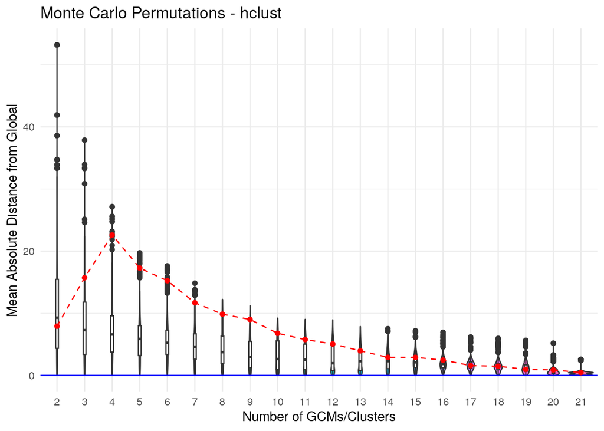

```
##
## $suggested_gcms
## $suggested_gcms$k2
## [1] "MRI-ESM2-0"  "UKESM1-0-LL"
##
## $suggested_gcms$k3
## [1] "MRI-ESM2-0"    "UKESM1-0-LL"   "CanESM5-CanOE"
##
## $suggested_gcms$k4
## [1] "MRI-ESM2-0"    "UKESM1-0-LL"   "CanESM5-CanOE" "MPI-ESM1-2-HR"
##
## $suggested_gcms$k5
## [1] "MRI-ESM2-0"    "UKESM1-0-LL"   "CanESM5-CanOE" "IPSL-CM6A-LR"
## [5] "MPI-ESM1-2-HR"
##
## $suggested_gcms$k6
## [1] "MRI-ESM2-0"    "UKESM1-0-LL"   "CanESM5-CanOE" "IPSL-CM6A-LR"
## [5] "GISS-E2-1-G"   "MPI-ESM1-2-HR"
##
## $suggested_gcms$k7
## [1] "MRI-ESM2-0"    "UKESM1-0-LL"   "CanESM5-CanOE" "IPSL-CM6A-LR"
## [5] "GISS-E2-1-G"   "MIROC6"        "MPI-ESM1-2-HR"
##
## $suggested_gcms$k8
## [1] "MRI-ESM2-0"    "UKESM1-0-LL"   "CanESM5-CanOE" "EC-Earth3-Veg"
## [5] "GISS-E2-1-G"   "MIROC6"        "IPSL-CM6A-LR"  "MPI-ESM1-2-HR"
##
## $suggested_gcms$k9
## [1] "ACCESS-CM2"    "UKESM1-0-LL"   "CanESM5-CanOE" "MRI-ESM2-0"
## [5] "EC-Earth3-Veg" "GISS-E2-1-G"   "MIROC6"        "IPSL-CM6A-LR"
## [9] "MPI-ESM1-2-HR"
##
## $suggested_gcms$k10
##  [1] "ACCESS-CM2"    "UKESM1-0-LL"   "CanESM5-CanOE" "MRI-ESM2-0"
##  [5] "EC-Earth3-Veg" "CNRM-ESM2-1"   "GISS-E2-1-G"   "MIROC6"
##  [9] "IPSL-CM6A-LR"  "MPI-ESM1-2-HR"
##
## $suggested_gcms$k11
##  [1] "ACCESS-CM2"    "UKESM1-0-LL"   "CanESM5-CanOE" "MRI-ESM2-0"
##  [5] "CNRM-CM6-1"    "CNRM-ESM2-1"   "EC-Earth3-Veg" "GISS-E2-1-G"
```

[output cut: 51 more lines]

```
##
## $suggested_gcms$k20
##  [1] "ACCESS-CM2"       "UKESM1-0-LL"      "CanESM5-CanOE"    "CMCC-ESM2"
##  [5] "CNRM-CM6-1"       "CNRM-ESM2-1"      "EC-Earth3-Veg"    "EC-Earth3-Veg-LR"
##  [9] "FIO-ESM-2-0"      "GISS-E2-1-G"      "GISS-E2-1-H"      "HadGEM3-GC31-LL"
## [13] "INM-CM4-8"        "INM-CM5-0"        "IPSL-CM6A-LR"     "MIROC-ES2L"
## [17] "MIROC6"           "MPI-ESM1-2-HR"    "MPI-ESM1-2-LR"    "MRI-ESM2-0"
##
## $suggested_gcms$k21
##  [1] "ACCESS-CM2"       "ACCESS-ESM1-5"    "CanESM5-CanOE"    "CMCC-ESM2"
##  [5] "CNRM-CM6-1"       "CNRM-ESM2-1"      "EC-Earth3-Veg"    "EC-Earth3-Veg-LR"
##  [9] "FIO-ESM-2-0"      "GISS-E2-1-G"      "GISS-E2-1-H"      "HadGEM3-GC31-LL"
## [13] "INM-CM4-8"        "INM-CM5-0"        "IPSL-CM6A-LR"     "MIROC-ES2L"
## [17] "MIROC6"           "MPI-ESM1-2-HR"    "MPI-ESM1-2-LR"    "MRI-ESM2-0"
## [21] "UKESM1-0-LL"
```

```r
tictoc::tic("Hierarchical Clustering 300")
mc_hclust_300 <- montecarlo_gcms(s10,
                             var_names = c("bio1", "bio12"),
                             study_area = buffer300,
                             scale = TRUE,
                             perm = 10000,
                             dist_method = "euclidean",
                             clustering_method = "hclust")
mc_hclust_300
```

```r
hclust_300 <- mc_hclust_300$suggested_gcms$k3
tictoc::toc()
```

```
## Hierarchical Clustering 300: 12.689 sec elapsed
```

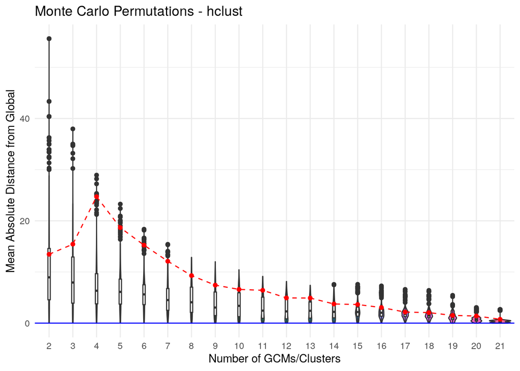

```
##
## $suggested_gcms
## $suggested_gcms$k2
## [1] "ACCESS-ESM1-5" "CNRM-CM6-1-HR"
##
## $suggested_gcms$k3
## [1] "ACCESS-ESM1-5" "CNRM-CM6-1-HR" "MPI-ESM1-2-HR"
##
## $suggested_gcms$k4
## [1] "ACCESS-ESM1-5" "CanESM5-CanOE" "CNRM-CM6-1-HR" "MPI-ESM1-2-HR"
##
## $suggested_gcms$k5
## [1] "MRI-ESM2-0"    "ACCESS-ESM1-5" "CanESM5-CanOE" "CNRM-CM6-1-HR"
## [5] "MPI-ESM1-2-HR"
##
## $suggested_gcms$k6
## [1] "MRI-ESM2-0"    "ACCESS-ESM1-5" "CanESM5-CanOE" "CNRM-CM6-1-HR"
## [5] "GISS-E2-1-G"   "MPI-ESM1-2-HR"
##
## $suggested_gcms$k7
## [1] "MRI-ESM2-0"    "ACCESS-ESM1-5" "CanESM5-CanOE" "CNRM-CM6-1"
## [5] "CNRM-CM6-1-HR" "GISS-E2-1-G"   "MPI-ESM1-2-HR"
##
## $suggested_gcms$k8
## [1] "MRI-ESM2-0"    "ACCESS-ESM1-5" "CanESM5-CanOE" "CNRM-CM6-1"
## [5] "CNRM-CM6-1-HR" "GISS-E2-1-G"   "INM-CM5-0"     "MPI-ESM1-2-HR"
##
## $suggested_gcms$k9
## [1] "MRI-ESM2-0"    "ACCESS-ESM1-5" "CanESM5-CanOE" "CNRM-CM6-1"
## [5] "CNRM-CM6-1-HR" "EC-Earth3-Veg" "GISS-E2-1-G"   "INM-CM5-0"
## [9] "MPI-ESM1-2-HR"
##
## $suggested_gcms$k10
##  [1] "MRI-ESM2-0"    "ACCESS-ESM1-5" "CanESM5-CanOE" "CMCC-ESM2"
##  [5] "CNRM-CM6-1"    "CNRM-CM6-1-HR" "EC-Earth3-Veg" "GISS-E2-1-G"
##  [9] "INM-CM5-0"     "MPI-ESM1-2-HR"
##
## $suggested_gcms$k11
##  [1] "MRI-ESM2-0"    "ACCESS-ESM1-5" "CanESM5-CanOE" "CMCC-ESM2"
##  [5] "CNRM-CM6-1"    "CNRM-CM6-1-HR" "EC-Earth3-Veg" "GISS-E2-1-G"
```

[output cut: 51 more lines]

```
##
## $suggested_gcms$k20
##  [1] "ACCESS-CM2"       "ACCESS-ESM1-5"    "CanESM5-CanOE"    "CMCC-ESM2"
##  [5] "CNRM-CM6-1"       "CNRM-CM6-1-HR"    "EC-Earth3-Veg"    "EC-Earth3-Veg-LR"
##  [9] "FIO-ESM-2-0"      "GISS-E2-1-G"      "GISS-E2-1-H"      "HadGEM3-GC31-LL"
## [13] "INM-CM4-8"        "INM-CM5-0"        "IPSL-CM6A-LR"     "MIROC-ES2L"
## [17] "MIROC6"           "MPI-ESM1-2-HR"    "MPI-ESM1-2-LR"    "MRI-ESM2-0"
##
## $suggested_gcms$k21
##  [1] "ACCESS-CM2"       "ACCESS-ESM1-5"    "CanESM5-CanOE"    "CMCC-ESM2"
##  [5] "CNRM-CM6-1"       "CNRM-CM6-1-HR"    "EC-Earth3-Veg"    "EC-Earth3-Veg-LR"
##  [9] "FIO-ESM-2-0"      "GISS-E2-1-G"      "GISS-E2-1-H"      "HadGEM3-GC31-LL"
## [13] "INM-CM4-8"        "INM-CM5-0"        "IPSL-CM6A-LR"     "MIROC-ES2L"
## [17] "MIROC6"           "MPI-ESM1-2-HR"    "MPI-ESM1-2-LR"    "MRI-ESM2-0"
## [21] "UKESM1-0-LL"
```

```r
tictoc::tic("Hierarchical Clustering 350")
mc_hclust_350 <- montecarlo_gcms(s10,
                             var_names = c("bio1", "bio12"),
                             study_area = buffer350,
                             scale = TRUE,
                             perm = 10000,
                             dist_method = "euclidean",
                             clustering_method = "hclust")
mc_hclust_350
```

```r
hclust_350 <- mc_hclust_350$suggested_gcms$k3
tictoc::toc()
```

```
## Hierarchical Clustering 350: 12.966 sec elapsed
```

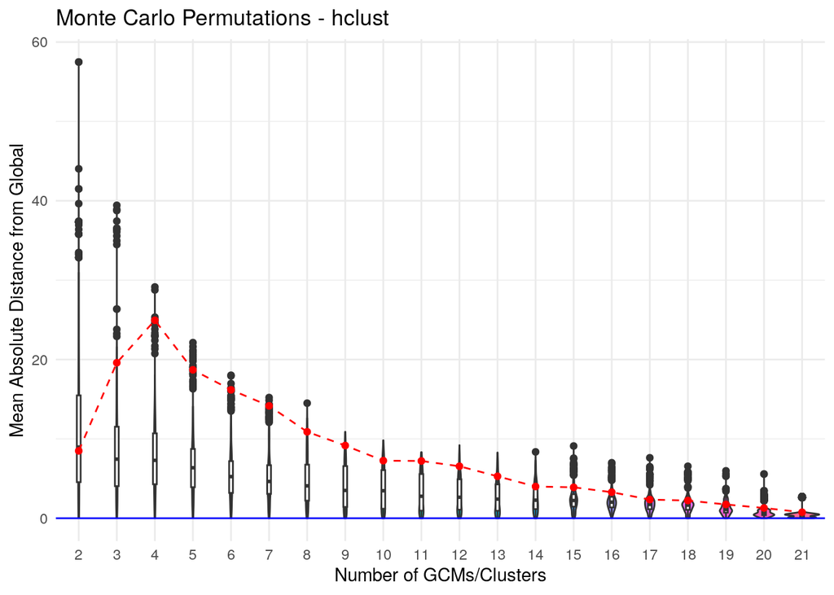

```
##
## $suggested_gcms
## $suggested_gcms$k2
## [1] "MRI-ESM2-0"   "IPSL-CM6A-LR"
##
## $suggested_gcms$k3
## [1] "MRI-ESM2-0"    "IPSL-CM6A-LR"  "MPI-ESM1-2-HR"
##
## $suggested_gcms$k4
## [1] "MRI-ESM2-0"    "CanESM5-CanOE" "IPSL-CM6A-LR"  "MPI-ESM1-2-HR"
##
## $suggested_gcms$k5
## [1] "MRI-ESM2-0"    "UKESM1-0-LL"   "CanESM5-CanOE" "IPSL-CM6A-LR"
## [5] "MPI-ESM1-2-HR"
##
## $suggested_gcms$k6
## [1] "MRI-ESM2-0"    "UKESM1-0-LL"   "CanESM5-CanOE" "IPSL-CM6A-LR"
## [5] "GISS-E2-1-G"   "MPI-ESM1-2-HR"
##
## $suggested_gcms$k7
## [1] "MRI-ESM2-0"       "UKESM1-0-LL"      "CanESM5-CanOE"    "IPSL-CM6A-LR"
## [5] "EC-Earth3-Veg-LR" "GISS-E2-1-G"      "MPI-ESM1-2-HR"
##
## $suggested_gcms$k8
## [1] "MRI-ESM2-0"       "UKESM1-0-LL"      "CanESM5-CanOE"    "IPSL-CM6A-LR"
## [5] "EC-Earth3-Veg-LR" "GISS-E2-1-G"      "MIROC-ES2L"       "MPI-ESM1-2-HR"
##
## $suggested_gcms$k9
## [1] "MRI-ESM2-0"       "UKESM1-0-LL"      "CanESM5-CanOE"    "IPSL-CM6A-LR"
## [5] "CNRM-CM6-1-HR"    "EC-Earth3-Veg-LR" "GISS-E2-1-G"      "MIROC-ES2L"
## [9] "MPI-ESM1-2-HR"
##
## $suggested_gcms$k10
##  [1] "MRI-ESM2-0"       "UKESM1-0-LL"      "CanESM5-CanOE"    "CNRM-CM6-1"
##  [5] "CNRM-CM6-1-HR"    "EC-Earth3-Veg-LR" "GISS-E2-1-G"      "MIROC-ES2L"
##  [9] "IPSL-CM6A-LR"     "MPI-ESM1-2-HR"
##
## $suggested_gcms$k11
##  [1] "ACCESS-CM2"       "UKESM1-0-LL"      "CanESM5-CanOE"    "MRI-ESM2-0"
##  [5] "CNRM-CM6-1"       "CNRM-CM6-1-HR"    "EC-Earth3-Veg-LR" "GISS-E2-1-G"
```

[output cut: 51 more lines]

```
##
## $suggested_gcms$k20
##  [1] "ACCESS-CM2"       "ACCESS-ESM1-5"    "CanESM5-CanOE"    "CMCC-ESM2"
##  [5] "CNRM-CM6-1"       "CNRM-CM6-1-HR"    "EC-Earth3-Veg"    "EC-Earth3-Veg-LR"
##  [9] "FIO-ESM-2-0"      "GISS-E2-1-G"      "GISS-E2-1-H"      "UKESM1-0-LL"
## [13] "INM-CM4-8"        "INM-CM5-0"        "IPSL-CM6A-LR"     "MIROC-ES2L"
## [17] "MIROC6"           "MPI-ESM1-2-HR"    "MPI-ESM1-2-LR"    "MRI-ESM2-0"
##
## $suggested_gcms$k21
##  [1] "ACCESS-CM2"       "ACCESS-ESM1-5"    "CanESM5-CanOE"    "CMCC-ESM2"
##  [5] "CNRM-CM6-1"       "CNRM-CM6-1-HR"    "EC-Earth3-Veg"    "EC-Earth3-Veg-LR"
##  [9] "FIO-ESM-2-0"      "GISS-E2-1-G"      "GISS-E2-1-H"      "HadGEM3-GC31-LL"
## [13] "INM-CM4-8"        "INM-CM5-0"        "IPSL-CM6A-LR"     "MIROC-ES2L"
## [17] "MIROC6"           "MPI-ESM1-2-HR"    "MPI-ESM1-2-LR"    "MRI-ESM2-0"
## [21] "UKESM1-0-LL"
```

```r
tictoc::tic("Hierarchical Clustering 400")
mc_hclust_400 <- montecarlo_gcms(s10,
                             var_names = c("bio1", "bio12"),
                             study_area = buffer400,
                             scale = TRUE,
                             perm = 10000,
                             dist_method = "euclidean",
                             clustering_method = "hclust")
mc_hclust_400
```

```r
hclust_400 <- mc_hclust_400$suggested_gcms$k3
tictoc::toc()
```

```
## Hierarchical Clustering 400: 13.137 sec elapsed
```

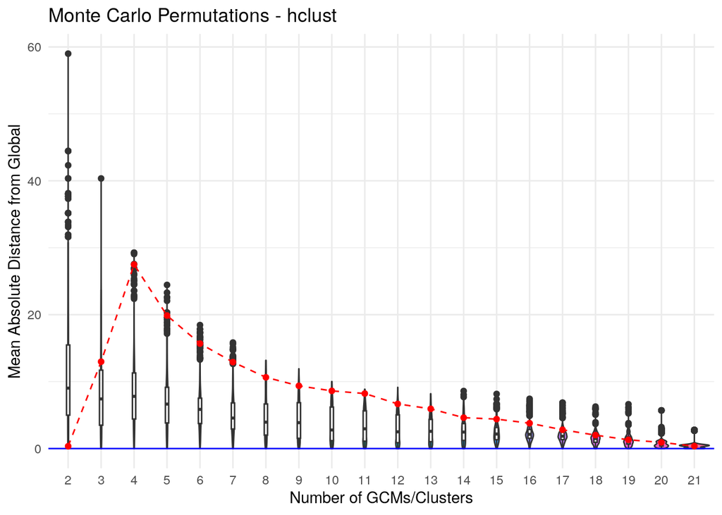

```
##
## $suggested_gcms
## $suggested_gcms$k2
## [1] "FIO-ESM-2-0" "CNRM-ESM2-1"
##
## $suggested_gcms$k3
## [1] "FIO-ESM-2-0"   "CNRM-ESM2-1"   "MPI-ESM1-2-HR"
##
## $suggested_gcms$k4
## [1] "FIO-ESM-2-0"   "CanESM5-CanOE" "CNRM-ESM2-1"   "MPI-ESM1-2-HR"
##
## $suggested_gcms$k5
## [1] "FIO-ESM-2-0"   "MIROC-ES2L"    "CanESM5-CanOE" "CNRM-ESM2-1"
## [5] "MPI-ESM1-2-HR"
##
## $suggested_gcms$k6
## [1] "FIO-ESM-2-0"   "MIROC-ES2L"    "CanESM5-CanOE" "CNRM-ESM2-1"
## [5] "GISS-E2-1-G"   "MPI-ESM1-2-HR"
##
## $suggested_gcms$k7
## [1] "FIO-ESM-2-0"   "MIROC-ES2L"    "CanESM5-CanOE" "INM-CM4-8"
## [5] "CNRM-ESM2-1"   "GISS-E2-1-G"   "MPI-ESM1-2-HR"
##
## $suggested_gcms$k8
## [1] "FIO-ESM-2-0"   "ACCESS-ESM1-5" "CanESM5-CanOE" "INM-CM4-8"
## [5] "CNRM-ESM2-1"   "GISS-E2-1-G"   "MIROC-ES2L"    "MPI-ESM1-2-HR"
##
## $suggested_gcms$k9
## [1] "FIO-ESM-2-0"      "ACCESS-ESM1-5"    "CanESM5-CanOE"    "INM-CM4-8"
## [5] "CNRM-ESM2-1"      "EC-Earth3-Veg-LR" "GISS-E2-1-G"      "MIROC-ES2L"
## [9] "MPI-ESM1-2-HR"
##
## $suggested_gcms$k10
##  [1] "ACCESS-CM2"       "ACCESS-ESM1-5"    "CanESM5-CanOE"    "FIO-ESM-2-0"
##  [5] "INM-CM4-8"        "CNRM-ESM2-1"      "EC-Earth3-Veg-LR" "GISS-E2-1-G"
##  [9] "MIROC-ES2L"       "MPI-ESM1-2-HR"
##
## $suggested_gcms$k11
##  [1] "ACCESS-CM2"       "ACCESS-ESM1-5"    "CanESM5-CanOE"    "FIO-ESM-2-0"
##  [5] "INM-CM4-8"        "CNRM-ESM2-1"      "EC-Earth3-Veg-LR" "GISS-E2-1-G"
```

[output cut: 51 more lines]

```
##
## $suggested_gcms$k20
##  [1] "ACCESS-CM2"       "ACCESS-ESM1-5"    "CanESM5-CanOE"    "CMCC-ESM2"
##  [5] "CNRM-CM6-1"       "CNRM-ESM2-1"      "EC-Earth3-Veg"    "EC-Earth3-Veg-LR"
##  [9] "FIO-ESM-2-0"      "GISS-E2-1-G"      "GISS-E2-1-H"      "UKESM1-0-LL"
## [13] "INM-CM4-8"        "INM-CM5-0"        "IPSL-CM6A-LR"     "MIROC-ES2L"
## [17] "MIROC6"           "MPI-ESM1-2-HR"    "MPI-ESM1-2-LR"    "MRI-ESM2-0"
##
## $suggested_gcms$k21
##  [1] "ACCESS-CM2"       "ACCESS-ESM1-5"    "CanESM5-CanOE"    "CMCC-ESM2"
##  [5] "CNRM-CM6-1"       "CNRM-ESM2-1"      "EC-Earth3-Veg"    "EC-Earth3-Veg-LR"
##  [9] "FIO-ESM-2-0"      "GISS-E2-1-G"      "GISS-E2-1-H"      "HadGEM3-GC31-LL"
## [13] "INM-CM4-8"        "INM-CM5-0"        "IPSL-CM6A-LR"     "MIROC-ES2L"
## [17] "MIROC6"           "MPI-ESM1-2-HR"    "MPI-ESM1-2-LR"    "MRI-ESM2-0"
## [21] "UKESM1-0-LL"
```

```r
tictoc::tic("Hierarchical Clustering 450")
mc_hclust_450 <- montecarlo_gcms(s10,
                             var_names = c("bio1", "bio12"),
                             study_area = buffer450,
                             scale = TRUE,
                             perm = 10000,
                             dist_method = "euclidean",
                             clustering_method = "hclust")
mc_hclust_450
```

```r
hclust_450 <- mc_hclust_450$suggested_gcms$k3
tictoc::toc()
```

```
## Hierarchical Clustering 450: 13.076 sec elapsed
```

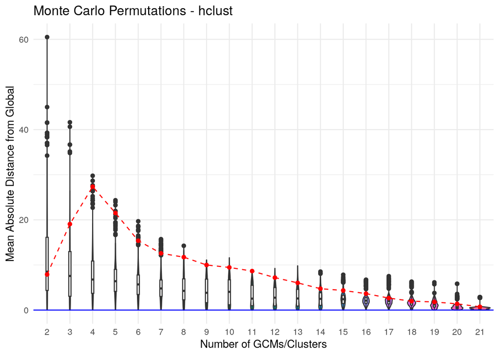

```
##
## $suggested_gcms
## $suggested_gcms$k2
## [1] "ACCESS-ESM1-5"    "EC-Earth3-Veg-LR"
##
## $suggested_gcms$k3
## [1] "ACCESS-ESM1-5"    "EC-Earth3-Veg-LR" "MPI-ESM1-2-HR"
##
## $suggested_gcms$k4
## [1] "ACCESS-ESM1-5"    "CanESM5-CanOE"    "EC-Earth3-Veg-LR" "MPI-ESM1-2-HR"
##
## $suggested_gcms$k5
## [1] "ACCESS-ESM1-5"    "CanESM5-CanOE"    "CMCC-ESM2"        "EC-Earth3-Veg-LR"
## [5] "MPI-ESM1-2-HR"
##
## $suggested_gcms$k6
## [1] "ACCESS-ESM1-5"    "CanESM5-CanOE"    "CMCC-ESM2"        "EC-Earth3-Veg-LR"
## [5] "MPI-ESM1-2-LR"    "MPI-ESM1-2-HR"
##
## $suggested_gcms$k7
## [1] "ACCESS-ESM1-5"    "CanESM5-CanOE"    "CMCC-ESM2"        "INM-CM4-8"
## [5] "EC-Earth3-Veg-LR" "MPI-ESM1-2-LR"    "MPI-ESM1-2-HR"
##
## $suggested_gcms$k8
## [1] "ACCESS-ESM1-5"    "CanESM5-CanOE"    "CMCC-ESM2"        "INM-CM4-8"
## [5] "EC-Earth3-Veg-LR" "GISS-E2-1-H"      "MPI-ESM1-2-LR"    "MPI-ESM1-2-HR"
##
## $suggested_gcms$k9
## [1] "ACCESS-ESM1-5"    "CanESM5-CanOE"    "CMCC-ESM2"        "INM-CM4-8"
## [5] "CNRM-CM6-1-HR"    "EC-Earth3-Veg-LR" "GISS-E2-1-H"      "MPI-ESM1-2-LR"
## [9] "MPI-ESM1-2-HR"
##
## $suggested_gcms$k10
##  [1] "ACCESS-CM2"       "ACCESS-ESM1-5"    "CanESM5-CanOE"    "CMCC-ESM2"
##  [5] "INM-CM4-8"        "CNRM-CM6-1-HR"    "EC-Earth3-Veg-LR" "GISS-E2-1-H"
##  [9] "MPI-ESM1-2-LR"    "MPI-ESM1-2-HR"
##
## $suggested_gcms$k11
##  [1] "ACCESS-CM2"       "ACCESS-ESM1-5"    "CanESM5-CanOE"    "CMCC-ESM2"
##  [5] "INM-CM4-8"        "CNRM-CM6-1-HR"    "EC-Earth3-Veg-LR" "GISS-E2-1-H"
```

[output cut: 51 more lines]

```
##
## $suggested_gcms$k20
##  [1] "ACCESS-CM2"       "ACCESS-ESM1-5"    "CanESM5-CanOE"    "CMCC-ESM2"
##  [5] "CNRM-CM6-1"       "CNRM-CM6-1-HR"    "EC-Earth3-Veg"    "EC-Earth3-Veg-LR"
##  [9] "FIO-ESM-2-0"      "GISS-E2-1-G"      "GISS-E2-1-H"      "HadGEM3-GC31-LL"
## [13] "INM-CM4-8"        "INM-CM5-0"        "IPSL-CM6A-LR"     "MIROC-ES2L"
## [17] "MIROC6"           "MPI-ESM1-2-HR"    "MPI-ESM1-2-LR"    "MRI-ESM2-0"
##
## $suggested_gcms$k21
##  [1] "ACCESS-CM2"       "ACCESS-ESM1-5"    "CanESM5-CanOE"    "CMCC-ESM2"
##  [5] "CNRM-CM6-1"       "CNRM-CM6-1-HR"    "EC-Earth3-Veg"    "EC-Earth3-Veg-LR"
##  [9] "FIO-ESM-2-0"      "GISS-E2-1-G"      "GISS-E2-1-H"      "HadGEM3-GC31-LL"
## [13] "INM-CM4-8"        "INM-CM5-0"        "IPSL-CM6A-LR"     "MIROC-ES2L"
## [17] "MIROC6"           "MPI-ESM1-2-HR"    "MPI-ESM1-2-LR"    "MRI-ESM2-0"
## [21] "UKESM1-0-LL"
```

```r
tictoc::tic("Hierarchical Clustering 500")
mc_hclust_500 <- montecarlo_gcms(s10,
                             var_names = c("bio1", "bio12"),
                             study_area = buffer500,
                             scale = TRUE,
                             perm = 10000,
                             dist_method = "euclidean",
                             clustering_method = "hclust")
mc_hclust_500
```

```r
hclust_500 <- mc_hclust_500$suggested_gcms$k3
tictoc::toc()
```

```
## Hierarchical Clustering 500: 13.193 sec elapsed
```

### K-means Clustering selection

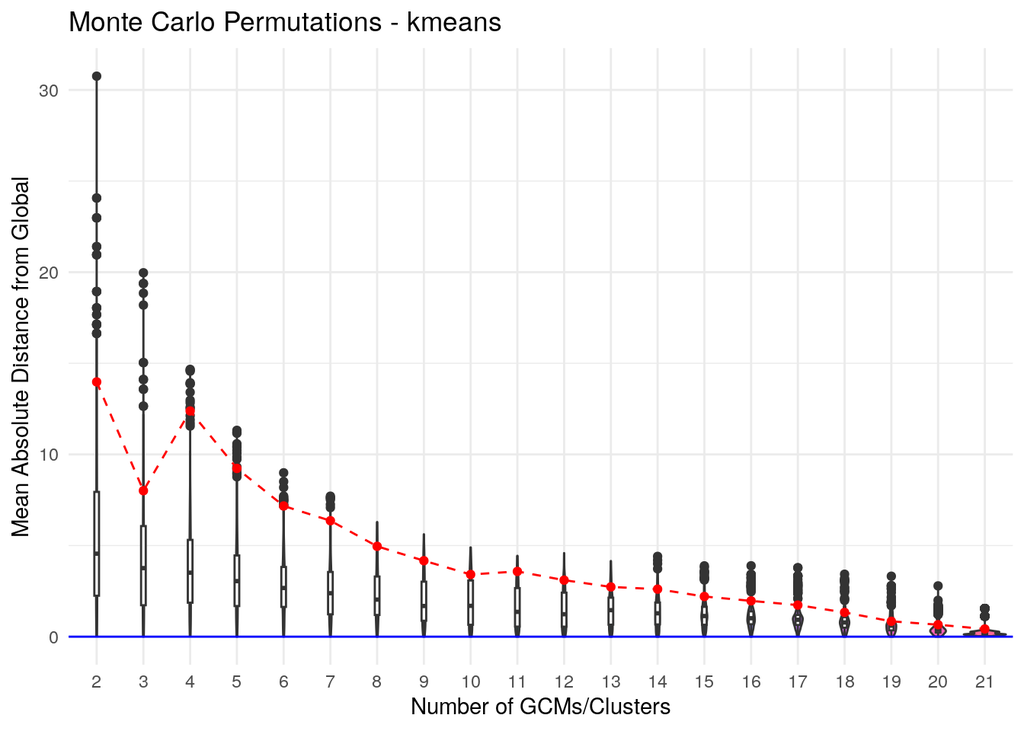

```
##
## $suggested_gcms
## $suggested_gcms$k2
##               1               2
##   "CNRM-ESM2-1" "CanESM5-CanOE"
##
## $suggested_gcms$k3
##               1               2               3
##   "CNRM-ESM2-1" "CanESM5-CanOE"    "MRI-ESM2-0"
##
## $suggested_gcms$k4
##               1               2               3               4
## "MPI-ESM1-2-HR"   "CNRM-ESM2-1" "CanESM5-CanOE"    "MRI-ESM2-0"
##
## $suggested_gcms$k5
##               1               2               3               4               5
## "CanESM5-CanOE"    "MRI-ESM2-0" "MPI-ESM1-2-HR"     "INM-CM4-8"   "UKESM1-0-LL"
##
## $suggested_gcms$k6
##               1               2               3               4               5
## "MPI-ESM1-2-HR"     "INM-CM4-8" "CanESM5-CanOE"   "UKESM1-0-LL"   "FIO-ESM-2-0"
##               6
##    "MRI-ESM2-0"
##
## $suggested_gcms$k7
##               1               2               3               4               5
##  "IPSL-CM6A-LR" "CanESM5-CanOE"    "MRI-ESM2-0" "MPI-ESM1-2-HR"   "UKESM1-0-LL"
##               6               7
## "EC-Earth3-Veg"   "FIO-ESM-2-0"
##
## $suggested_gcms$k8
##               1               2               3               4               5
##  "IPSL-CM6A-LR" "CanESM5-CanOE" "CNRM-CM6-1-HR" "EC-Earth3-Veg"   "FIO-ESM-2-0"
##               6               7               8
## "MPI-ESM1-2-HR"   "UKESM1-0-LL"    "MRI-ESM2-0"
##
## $suggested_gcms$k9
##               1               2               3               4               5
##   "CNRM-ESM2-1"     "INM-CM4-8"   "UKESM1-0-LL"    "MRI-ESM2-0" "CanESM5-CanOE"
##               6               7               8               9
```

[output cut: 104 more lines]

```
##       "ACCESS-CM2"    "EC-Earth3-Veg"      "GISS-E2-1-G"     "IPSL-CM6A-LR"
##
## $suggested_gcms$k21
##                  1                  2                  3                  4
##    "CNRM-CM6-1-HR"           "MIROC6"      "GISS-E2-1-G"    "MPI-ESM1-2-LR"
##                  5                  6                  7                  8
##       "MIROC-ES2L"       "ACCESS-CM2"     "IPSL-CM6A-LR"    "EC-Earth3-Veg"
##                  9                 10                 11                 12
##    "ACCESS-ESM1-5"  "HadGEM3-GC31-LL"       "CNRM-CM6-1"      "UKESM1-0-LL"
##                 13                 14                 15                 16
##        "INM-CM5-0" "EC-Earth3-Veg-LR"        "CMCC-ESM2"    "MPI-ESM1-2-HR"
##                 17                 18                 19                 20
##      "FIO-ESM-2-0"       "MRI-ESM2-0"        "INM-CM4-8"      "GISS-E2-1-H"
##                 21
##    "CanESM5-CanOE"
```

```r
tictoc::tic("K-means Clustering 50")
mc_kmeans_50 <- montecarlo_gcms(s10,
                             var_names = c("bio1", "bio12"),
                             study_area = buffer50,
                             scale = TRUE,
                             perm = 10000,
                             dist_method = "euclidean",
                             clustering_method = "kmeans")
mc_kmeans_50
```

```r
kmeans_50 <- mc_kmeans_50$suggested_gcms$k3
tictoc::toc()
```

```
## K-means Clustering 50: 22.477 sec elapsed
```

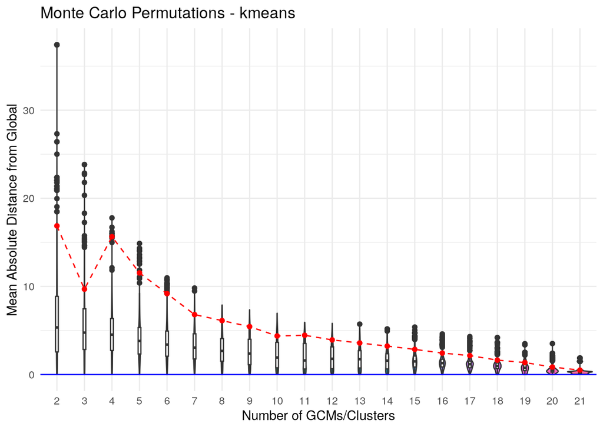

```
##
## $suggested_gcms
## $suggested_gcms$k2
##               1               2
## "CanESM5-CanOE"   "CNRM-ESM2-1"
##
## $suggested_gcms$k3
##               1               2               3
##    "MRI-ESM2-0" "CanESM5-CanOE"   "CNRM-ESM2-1"
##
## $suggested_gcms$k4
##               1               2               3               4
##   "CNRM-ESM2-1"    "MRI-ESM2-0" "CanESM5-CanOE" "MPI-ESM1-2-HR"
##
## $suggested_gcms$k5
##               1               2               3               4               5
##   "UKESM1-0-LL" "MPI-ESM1-2-HR"    "MRI-ESM2-0" "CanESM5-CanOE"     "INM-CM4-8"
##
## $suggested_gcms$k6
##               1               2               3               4               5
##     "INM-CM4-8" "CanESM5-CanOE"   "FIO-ESM-2-0" "MPI-ESM1-2-HR"   "UKESM1-0-LL"
##               6
##    "MRI-ESM2-0"
##
## $suggested_gcms$k7
##               1               2               3               4               5
##   "UKESM1-0-LL" "MPI-ESM1-2-HR"    "MRI-ESM2-0"   "FIO-ESM-2-0"   "CNRM-ESM2-1"
##               6               7
##     "INM-CM4-8" "CanESM5-CanOE"
##
## $suggested_gcms$k8
##               1               2               3               4               5
##   "CNRM-ESM2-1"     "INM-CM4-8"   "FIO-ESM-2-0"  "IPSL-CM6A-LR"   "UKESM1-0-LL"
##               6               7               8
## "CanESM5-CanOE" "MPI-ESM1-2-HR"    "MRI-ESM2-0"
##
## $suggested_gcms$k9
##               1               2               3               4               5
## "MPI-ESM1-2-HR"   "UKESM1-0-LL"    "MRI-ESM2-0"   "GISS-E2-1-G" "CanESM5-CanOE"
##               6               7               8               9
```

[output cut: 104 more lines]

```
##    "MPI-ESM1-2-HR"           "MIROC6"     "IPSL-CM6A-LR"      "FIO-ESM-2-0"
##
## $suggested_gcms$k21
##                  1                  2                  3                  4
##    "EC-Earth3-Veg"       "CNRM-CM6-1"        "INM-CM5-0"           "MIROC6"
##                  5                  6                  7                  8
##        "CMCC-ESM2"  "HadGEM3-GC31-LL"       "MIROC-ES2L"      "GISS-E2-1-G"
##                  9                 10                 11                 12
##     "IPSL-CM6A-LR"       "ACCESS-CM2"    "ACCESS-ESM1-5"      "GISS-E2-1-H"
##                 13                 14                 15                 16
##        "INM-CM4-8" "EC-Earth3-Veg-LR"    "MPI-ESM1-2-LR"    "CanESM5-CanOE"
##                 17                 18                 19                 20
##      "FIO-ESM-2-0"    "MPI-ESM1-2-HR"       "MRI-ESM2-0"    "CNRM-CM6-1-HR"
##                 21
##      "UKESM1-0-LL"
```

```r
tictoc::tic("K-means Clustering 100")
mc_kmeans_100 <- montecarlo_gcms(s10,
                             var_names = c("bio1", "bio12"),
                             study_area = buffer100,
                             scale = TRUE,
                             perm = 10000,
                             dist_method = "euclidean",
                             clustering_method = "kmeans")
mc_kmeans_100
```

```r
kmeans_100 <- mc_kmeans_100$suggested_gcms$k3
tictoc::toc()
```

```
## K-means Clustering 100: 22.801 sec elapsed
```

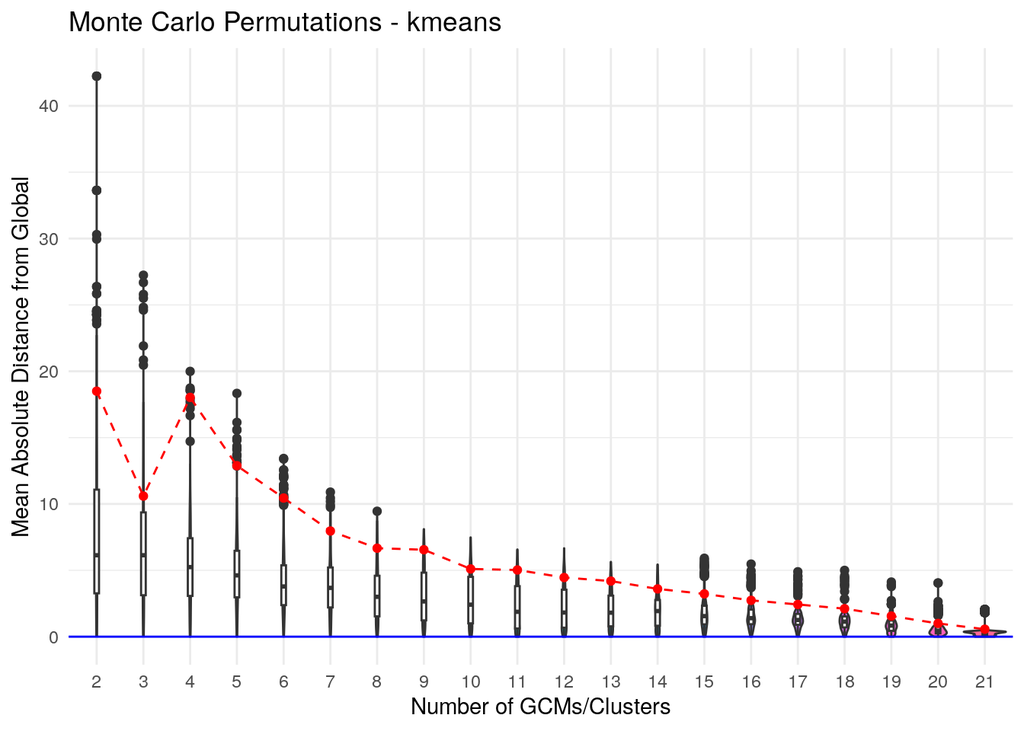

```
##
## $suggested_gcms
## $suggested_gcms$k2
##               1               2
##   "CNRM-ESM2-1" "CanESM5-CanOE"
##
## $suggested_gcms$k3
##               1               2               3
##   "CNRM-ESM2-1" "CanESM5-CanOE"    "MRI-ESM2-0"
##
## $suggested_gcms$k4
##               1               2               3               4
##    "MRI-ESM2-0" "CanESM5-CanOE" "MPI-ESM1-2-HR"   "CNRM-ESM2-1"
##
## $suggested_gcms$k5
##               1               2               3               4               5
## "MPI-ESM1-2-HR"    "MRI-ESM2-0" "CanESM5-CanOE"     "INM-CM4-8"   "CNRM-ESM2-1"
##
## $suggested_gcms$k6
##               1               2               3               4               5
## "CanESM5-CanOE"   "FIO-ESM-2-0" "MPI-ESM1-2-HR"    "MRI-ESM2-0"   "CNRM-ESM2-1"
##               6
##     "INM-CM4-8"
##
## $suggested_gcms$k7
##               1               2               3               4               5
##    "MRI-ESM2-0" "MPI-ESM1-2-HR"   "UKESM1-0-LL"   "CNRM-ESM2-1"   "FIO-ESM-2-0"
##               6               7
## "CanESM5-CanOE"     "INM-CM4-8"
##
## $suggested_gcms$k8
##               1               2               3               4               5
## "CanESM5-CanOE"   "GISS-E2-1-G" "MPI-ESM1-2-HR"    "MRI-ESM2-0"     "INM-CM4-8"
##               6               7               8
##   "CNRM-ESM2-1"   "FIO-ESM-2-0"   "UKESM1-0-LL"
##
## $suggested_gcms$k9
##               1               2               3               4               5
## "MPI-ESM1-2-HR"  "IPSL-CM6A-LR"   "UKESM1-0-LL"    "MRI-ESM2-0"   "CNRM-ESM2-1"
##               6               7               8               9
```

[output cut: 104 more lines]

```
##    "MPI-ESM1-2-HR"           "MIROC6"       "MIROC-ES2L"      "FIO-ESM-2-0"
##
## $suggested_gcms$k21
##                  1                  2                  3                  4
##  "HadGEM3-GC31-LL"        "INM-CM5-0"       "MRI-ESM2-0"     "IPSL-CM6A-LR"
##                  5                  6                  7                  8
##    "CNRM-CM6-1-HR"    "EC-Earth3-Veg"        "INM-CM4-8"    "ACCESS-ESM1-5"
##                  9                 10                 11                 12
## "EC-Earth3-Veg-LR"    "MPI-ESM1-2-HR"        "CMCC-ESM2"       "MIROC-ES2L"
##                 13                 14                 15                 16
##       "ACCESS-CM2"           "MIROC6"      "GISS-E2-1-G"      "GISS-E2-1-H"
##                 17                 18                 19                 20
##    "MPI-ESM1-2-LR"      "UKESM1-0-LL"    "CanESM5-CanOE"       "CNRM-CM6-1"
##                 21
##      "FIO-ESM-2-0"
```

```r
tictoc::tic("K-means Clustering 150")
mc_kmeans_150 <- montecarlo_gcms(s10,
                             var_names = c("bio1", "bio12"),
                             study_area = buffer150,
                             scale = TRUE,
                             perm = 10000,
                             dist_method = "euclidean",
                             clustering_method = "kmeans")
mc_kmeans_150
```

```r
kmeans_150 <- mc_kmeans_150$suggested_gcms$k3
tictoc::toc()
```

```
## K-means Clustering 150: 22.718 sec elapsed
```

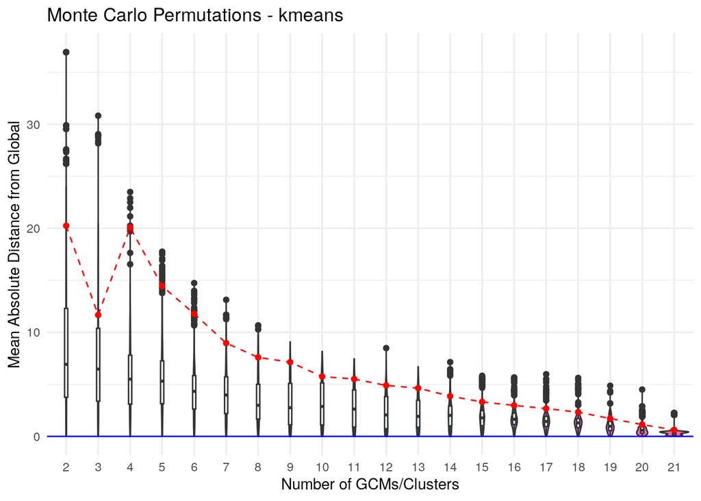

```
##
## $suggested_gcms
## $suggested_gcms$k2
##               1               2
##   "CNRM-ESM2-1" "CanESM5-CanOE"
##
## $suggested_gcms$k3
##               1               2               3
##    "MRI-ESM2-0" "CanESM5-CanOE"   "CNRM-ESM2-1"
##
## $suggested_gcms$k4
##               1               2               3               4
##   "CNRM-ESM2-1" "MPI-ESM1-2-HR" "CanESM5-CanOE"    "MRI-ESM2-0"
##
## $suggested_gcms$k5
##               1               2               3               4               5
##     "INM-CM4-8"   "CNRM-ESM2-1"    "MRI-ESM2-0" "CanESM5-CanOE" "MPI-ESM1-2-HR"
##
## $suggested_gcms$k6
##               1               2               3               4               5
##   "FIO-ESM-2-0"    "MRI-ESM2-0"     "INM-CM4-8" "CanESM5-CanOE" "MPI-ESM1-2-HR"
##               6
##   "CNRM-ESM2-1"
##
## $suggested_gcms$k7
##               1               2               3               4               5
##   "FIO-ESM-2-0"   "UKESM1-0-LL"    "MRI-ESM2-0" "MPI-ESM1-2-HR"   "CNRM-ESM2-1"
##               6               7
## "CanESM5-CanOE"     "INM-CM4-8"
##
## $suggested_gcms$k8
##               1               2               3               4               5
##   "GISS-E2-1-G" "MPI-ESM1-2-HR"    "MRI-ESM2-0"   "UKESM1-0-LL" "CanESM5-CanOE"
##               6               7               8
##   "CNRM-ESM2-1"   "FIO-ESM-2-0"     "INM-CM4-8"
##
## $suggested_gcms$k9
##               1               2               3               4               5
##   "FIO-ESM-2-0" "EC-Earth3-Veg" "CanESM5-CanOE"   "GISS-E2-1-G"   "UKESM1-0-LL"
##               6               7               8               9
```

[output cut: 106 more lines]

```
##      "GISS-E2-1-H"  "HadGEM3-GC31-LL"       "ACCESS-CM2"       "CNRM-CM6-1"
##
## $suggested_gcms$k21
##                  1                  2                  3                  4
##    "MPI-ESM1-2-HR"    "ACCESS-ESM1-5"      "UKESM1-0-LL" "EC-Earth3-Veg-LR"
##                  5                  6                  7                  8
##       "CNRM-CM6-1"     "IPSL-CM6A-LR"        "CMCC-ESM2"        "INM-CM5-0"
##                  9                 10                 11                 12
##           "MIROC6"    "CanESM5-CanOE"      "GISS-E2-1-G"      "FIO-ESM-2-0"
##                 13                 14                 15                 16
##       "MRI-ESM2-0"       "ACCESS-CM2"    "MPI-ESM1-2-LR"    "EC-Earth3-Veg"
##                 17                 18                 19                 20
##      "GISS-E2-1-H"    "CNRM-CM6-1-HR"  "HadGEM3-GC31-LL"       "MIROC-ES2L"
##                 21
##        "INM-CM4-8"
```

```r
tictoc::tic("K-means Clustering 200")
mc_kmeans_200 <- montecarlo_gcms(s10,
                             var_names = c("bio1", "bio12"),
                             study_area = buffer200,
                             scale = TRUE,
                             perm = 10000,
                             dist_method = "euclidean",
                             clustering_method = "kmeans")
mc_kmeans_200
```

```r
kmeans_200 <- mc_kmeans_200$suggested_gcms$k3
tictoc::toc()
```

```
## K-means Clustering 200: 23.178 sec elapsed
```

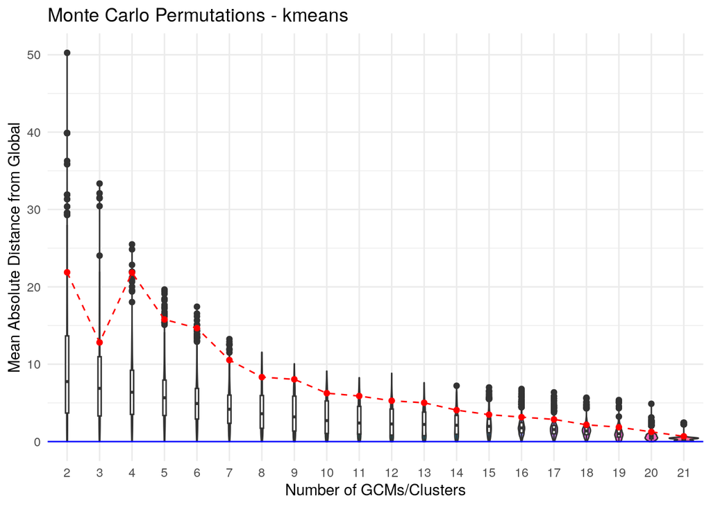

```
##
## $suggested_gcms
## $suggested_gcms$k2
##               1               2
##   "CNRM-ESM2-1" "CanESM5-CanOE"
##
## $suggested_gcms$k3
##               1               2               3
##   "CNRM-ESM2-1" "CanESM5-CanOE"    "MRI-ESM2-0"
##
## $suggested_gcms$k4
##               1               2               3               4
## "CanESM5-CanOE" "MPI-ESM1-2-HR"    "MRI-ESM2-0"   "CNRM-ESM2-1"
##
## $suggested_gcms$k5
##               1               2               3               4               5
##     "INM-CM4-8" "CanESM5-CanOE"   "CNRM-ESM2-1"    "MRI-ESM2-0" "MPI-ESM1-2-HR"
##
## $suggested_gcms$k6
##               1               2               3               4               5
## "MPI-ESM1-2-HR"   "FIO-ESM-2-0"     "INM-CM4-8"   "CNRM-ESM2-1" "CanESM5-CanOE"
##               6
##   "GISS-E2-1-G"
##
## $suggested_gcms$k7
##               1               2               3               4               5
##   "GISS-E2-1-G"   "FIO-ESM-2-0"   "CNRM-ESM2-1" "CanESM5-CanOE"    "MRI-ESM2-0"
##               6               7
## "MPI-ESM1-2-HR"     "INM-CM4-8"
##
## $suggested_gcms$k8
##               1               2               3               4               5
##   "CNRM-ESM2-1"    "MRI-ESM2-0" "CanESM5-CanOE"   "UKESM1-0-LL"   "FIO-ESM-2-0"
##               6               7               8
##     "INM-CM4-8"   "GISS-E2-1-G" "MPI-ESM1-2-HR"
##
## $suggested_gcms$k9
##               1               2               3               4               5
## "MPI-ESM1-2-HR"   "FIO-ESM-2-0"   "UKESM1-0-LL"    "MRI-ESM2-0"   "CNRM-ESM2-1"
##               6               7               8               9
```

[output cut: 106 more lines]

```
##      "GISS-E2-1-G"    "MPI-ESM1-2-HR"    "EC-Earth3-Veg"       "MRI-ESM2-0"
##
## $suggested_gcms$k21
##                  1                  2                  3                  4
##        "INM-CM4-8"       "ACCESS-CM2"    "CanESM5-CanOE"      "GISS-E2-1-H"
##                  5                  6                  7                  8
##    "MPI-ESM1-2-HR"       "CNRM-CM6-1"  "HadGEM3-GC31-LL"    "MPI-ESM1-2-LR"
##                  9                 10                 11                 12
##     "IPSL-CM6A-LR"    "EC-Earth3-Veg"      "FIO-ESM-2-0"        "INM-CM5-0"
##                 13                 14                 15                 16
##    "CNRM-CM6-1-HR"        "CMCC-ESM2"    "ACCESS-ESM1-5"       "MRI-ESM2-0"
##                 17                 18                 19                 20
##           "MIROC6"      "GISS-E2-1-G" "EC-Earth3-Veg-LR"       "MIROC-ES2L"
##                 21
##      "UKESM1-0-LL"
```

```r
tictoc::tic("K-means Clustering 250")
mc_kmeans_250 <- montecarlo_gcms(s10,
                             var_names = c("bio1", "bio12"),
                             study_area = buffer250,
                             scale = TRUE,
                             perm = 10000,
                             dist_method = "euclidean",
                             clustering_method = "kmeans")
mc_kmeans_250
```

```r
kmeans_250 <- mc_kmeans_250$suggested_gcms$k3
tictoc::toc()
```

```
## K-means Clustering 250: 23.802 sec elapsed
```

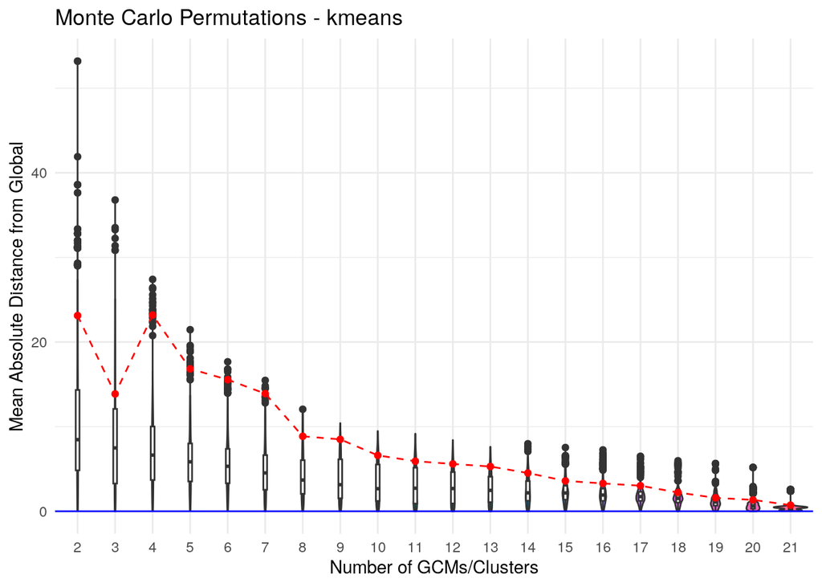

```
##
## $suggested_gcms
## $suggested_gcms$k2
##               1               2
##   "CNRM-ESM2-1" "CanESM5-CanOE"
##
## $suggested_gcms$k3
##               1               2               3
##   "CNRM-ESM2-1" "CanESM5-CanOE"    "MRI-ESM2-0"
##
## $suggested_gcms$k4
##               1               2               3               4
##   "CNRM-ESM2-1" "MPI-ESM1-2-HR"    "MRI-ESM2-0" "CanESM5-CanOE"
##
## $suggested_gcms$k5
##               1               2               3               4               5
##    "MRI-ESM2-0"   "CNRM-ESM2-1" "MPI-ESM1-2-HR" "CanESM5-CanOE"     "INM-CM4-8"
##
## $suggested_gcms$k6
##               1               2               3               4               5
## "MPI-ESM1-2-HR"     "INM-CM4-8" "CanESM5-CanOE"   "FIO-ESM-2-0"   "CNRM-ESM2-1"
##               6
##   "GISS-E2-1-G"
##
## $suggested_gcms$k7
##               1               2               3               4               5
## "CanESM5-CanOE"  "IPSL-CM6A-LR"   "FIO-ESM-2-0"   "GISS-E2-1-G" "EC-Earth3-Veg"
##               6               7
## "MPI-ESM1-2-HR"   "UKESM1-0-LL"
##
## $suggested_gcms$k8
##               1               2               3               4               5
##   "UKESM1-0-LL" "MPI-ESM1-2-HR"   "GISS-E2-1-G"     "INM-CM4-8" "CanESM5-CanOE"
##               6               7               8
##   "FIO-ESM-2-0"    "MRI-ESM2-0"   "CNRM-ESM2-1"
##
## $suggested_gcms$k9
##               1               2               3               4               5
##   "FIO-ESM-2-0"   "GISS-E2-1-G" "CanESM5-CanOE"   "CNRM-ESM2-1" "MPI-ESM1-2-HR"
##               6               7               8               9
```

[output cut: 108 more lines]

```
##       "CNRM-CM6-1"      "GISS-E2-1-H"    "CanESM5-CanOE"        "INM-CM5-0"
##
## $suggested_gcms$k21
##                  1                  2                  3                  4
##        "CMCC-ESM2"      "GISS-E2-1-H"    "MPI-ESM1-2-HR" "EC-Earth3-Veg-LR"
##                  5                  6                  7                  8
##       "MRI-ESM2-0"     "IPSL-CM6A-LR"      "GISS-E2-1-G"        "INM-CM4-8"
##                  9                 10                 11                 12
##    "ACCESS-ESM1-5"       "CNRM-CM6-1"       "MIROC-ES2L"    "CanESM5-CanOE"
##                 13                 14                 15                 16
##      "FIO-ESM-2-0"    "CNRM-CM6-1-HR"  "HadGEM3-GC31-LL"           "MIROC6"
##                 17                 18                 19                 20
##    "MPI-ESM1-2-LR"      "UKESM1-0-LL"    "EC-Earth3-Veg"        "INM-CM5-0"
##                 21
##       "ACCESS-CM2"
```

```r
tictoc::tic("K-means Clustering 300")
mc_kmeans_300 <- montecarlo_gcms(s10,
                             var_names = c("bio1", "bio12"),
                             study_area = buffer300,
                             scale = TRUE,
                             perm = 10000,
                             dist_method = "euclidean",
                             clustering_method = "kmeans")
mc_kmeans_300
```

```r
kmeans_300 <- mc_kmeans_300$suggested_gcms$k3
tictoc::toc()
```

```
## K-means Clustering 300: 23.46 sec elapsed
```

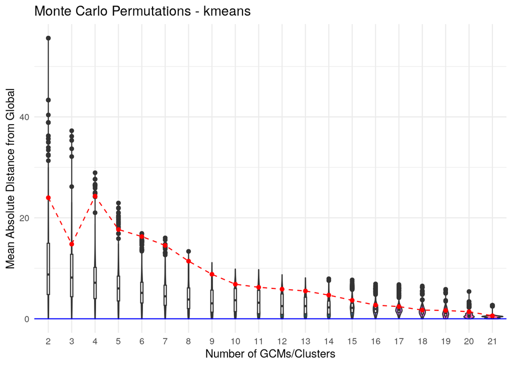

```
##
## $suggested_gcms
## $suggested_gcms$k2
##               1               2
##   "CNRM-ESM2-1" "CanESM5-CanOE"
##
## $suggested_gcms$k3
##               1               2               3
##    "MRI-ESM2-0"   "CNRM-ESM2-1" "CanESM5-CanOE"
##
## $suggested_gcms$k4
##               1               2               3               4
##   "CNRM-ESM2-1" "CanESM5-CanOE"    "MRI-ESM2-0" "MPI-ESM1-2-HR"
##
## $suggested_gcms$k5
##               1               2               3               4               5
##   "CNRM-ESM2-1" "CanESM5-CanOE"    "MRI-ESM2-0" "MPI-ESM1-2-HR"    "CNRM-CM6-1"
##
## $suggested_gcms$k6
##               1               2               3               4               5
## "CanESM5-CanOE"   "FIO-ESM-2-0"   "CNRM-ESM2-1" "MPI-ESM1-2-HR"    "CNRM-CM6-1"
##               6
##   "GISS-E2-1-G"
##
## $suggested_gcms$k7
##               1               2               3               4               5
##   "UKESM1-0-LL"  "IPSL-CM6A-LR"   "GISS-E2-1-G"   "FIO-ESM-2-0" "EC-Earth3-Veg"
##               6               7
## "CanESM5-CanOE" "MPI-ESM1-2-HR"
##
## $suggested_gcms$k8
##               1               2               3               4               5
## "EC-Earth3-Veg"   "FIO-ESM-2-0"    "MIROC-ES2L" "CanESM5-CanOE" "MPI-ESM1-2-HR"
##               6               7               8
##  "IPSL-CM6A-LR"   "GISS-E2-1-G"   "UKESM1-0-LL"
##
## $suggested_gcms$k9
##               1               2               3               4               5
##  "IPSL-CM6A-LR"   "GISS-E2-1-G"   "CNRM-ESM2-1"   "UKESM1-0-LL" "CanESM5-CanOE"
##               6               7               8               9
```

[output cut: 108 more lines]

```
##    "CNRM-CM6-1-HR"    "EC-Earth3-Veg"    "ACCESS-ESM1-5"      "GISS-E2-1-G"
##
## $suggested_gcms$k21
##                  1                  2                  3                  4
##      "CNRM-ESM2-1"    "MPI-ESM1-2-HR"      "GISS-E2-1-G"       "MIROC-ES2L"
##                  5                  6                  7                  8
##    "MPI-ESM1-2-LR"    "ACCESS-ESM1-5"  "HadGEM3-GC31-LL"    "CNRM-CM6-1-HR"
##                  9                 10                 11                 12
##    "CanESM5-CanOE"      "FIO-ESM-2-0"        "INM-CM5-0"     "IPSL-CM6A-LR"
##                 13                 14                 15                 16
##       "CNRM-CM6-1"       "MRI-ESM2-0"        "CMCC-ESM2"    "EC-Earth3-Veg"
##                 17                 18                 19                 20
##      "GISS-E2-1-H"        "INM-CM4-8"       "ACCESS-CM2" "EC-Earth3-Veg-LR"
##                 21
##           "MIROC6"
```

```r
tictoc::tic("K-means Clustering 350")
mc_kmeans_350 <- montecarlo_gcms(s10,
                             var_names = c("bio1", "bio12"),
                             study_area = buffer350,
                             scale = TRUE,
                             perm = 10000,
                             dist_method = "euclidean",
                             clustering_method = "kmeans")
mc_kmeans_350
```

```r
kmeans_350 <- mc_kmeans_350$suggested_gcms$k3
tictoc::toc()
```

```
## K-means Clustering 350: 23.938 sec elapsed
```

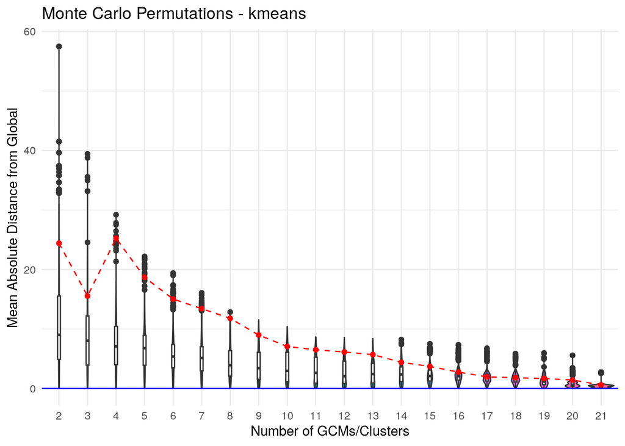

```
##
## $suggested_gcms
## $suggested_gcms$k2
##               1               2
## "CanESM5-CanOE"   "CNRM-ESM2-1"
##
## $suggested_gcms$k3
##               1               2               3
##   "CNRM-ESM2-1" "CanESM5-CanOE"    "MRI-ESM2-0"
##
## $suggested_gcms$k4
##               1               2               3               4
## "CanESM5-CanOE"   "CNRM-ESM2-1" "MPI-ESM1-2-HR"    "MRI-ESM2-0"
##
## $suggested_gcms$k5
##               1               2               3               4               5
## "MPI-ESM1-2-HR"    "CNRM-CM6-1"    "MRI-ESM2-0" "CanESM5-CanOE"   "UKESM1-0-LL"
##
## $suggested_gcms$k6
##               1               2               3               4               5
##    "MRI-ESM2-0" "MPI-ESM1-2-HR"   "FIO-ESM-2-0"    "CNRM-CM6-1" "CanESM5-CanOE"
##               6
##   "UKESM1-0-LL"
##
## $suggested_gcms$k7
##               1               2               3               4               5
## "CanESM5-CanOE" "MPI-ESM1-2-HR" "EC-Earth3-Veg"    "MRI-ESM2-0"   "UKESM1-0-LL"
##               6               7
##   "FIO-ESM-2-0"  "IPSL-CM6A-LR"
##
## $suggested_gcms$k8
##               1               2               3               4               5
##   "UKESM1-0-LL"  "IPSL-CM6A-LR"   "FIO-ESM-2-0" "EC-Earth3-Veg"    "MIROC-ES2L"
##               6               7               8
## "MPI-ESM1-2-HR" "CanESM5-CanOE"   "GISS-E2-1-G"
##
## $suggested_gcms$k9
##               1               2               3               4               5
##  "IPSL-CM6A-LR"   "UKESM1-0-LL"   "FIO-ESM-2-0"    "MIROC-ES2L" "CanESM5-CanOE"
##               6               7               8               9
```

[output cut: 106 more lines]

```
##    "MPI-ESM1-2-LR"        "INM-CM5-0"    "CanESM5-CanOE"      "FIO-ESM-2-0"
##
## $suggested_gcms$k21
##                  1                  2                  3                  4
##     "IPSL-CM6A-LR"       "CNRM-CM6-1"        "INM-CM4-8"       "MRI-ESM2-0"
##                  5                  6                  7                  8
##  "HadGEM3-GC31-LL"    "CNRM-CM6-1-HR"       "MIROC-ES2L"           "MIROC6"
##                  9                 10                 11                 12
##       "ACCESS-CM2"        "CMCC-ESM2"    "CanESM5-CanOE"      "FIO-ESM-2-0"
##                 13                 14                 15                 16
##      "GISS-E2-1-H"      "GISS-E2-1-G"    "MPI-ESM1-2-LR"    "EC-Earth3-Veg"
##                 17                 18                 19                 20
## "EC-Earth3-Veg-LR"      "CNRM-ESM2-1"    "MPI-ESM1-2-HR"        "INM-CM5-0"
##                 21
##    "ACCESS-ESM1-5"
```

```r
tictoc::tic("K-means Clustering 400")
mc_kmeans_400 <- montecarlo_gcms(s10,
                             var_names = c("bio1", "bio12"),
                             study_area = buffer400,
                             scale = TRUE,
                             perm = 10000,
                             dist_method = "euclidean",
                             clustering_method = "kmeans")
mc_kmeans_400
```

```r
kmeans_400 <- mc_kmeans_400$suggested_gcms$k3
tictoc::toc()
```

```
## K-means Clustering 400: 23.766 sec elapsed
```

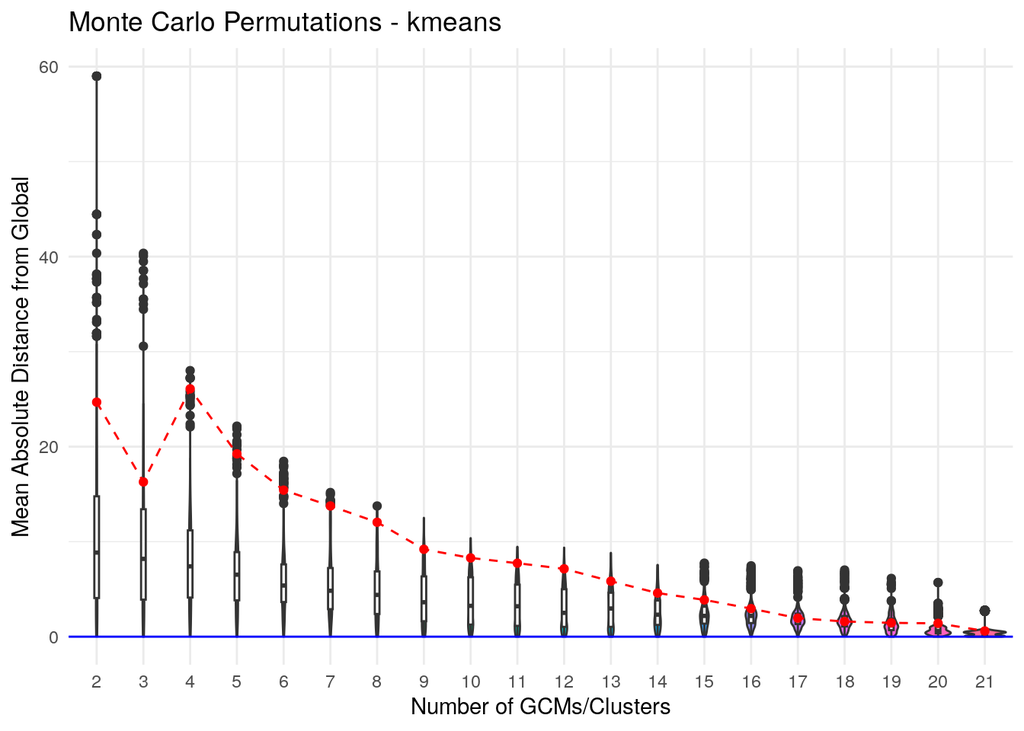

```
##
## $suggested_gcms
## $suggested_gcms$k2
##               1               2
## "CanESM5-CanOE"   "CNRM-ESM2-1"
##
## $suggested_gcms$k3
##               1               2               3
## "CanESM5-CanOE"   "CNRM-ESM2-1"    "MRI-ESM2-0"
##
## $suggested_gcms$k4
##               1               2               3               4
## "CanESM5-CanOE"    "MRI-ESM2-0" "MPI-ESM1-2-HR"   "CNRM-ESM2-1"
##
## $suggested_gcms$k5
##               1               2               3               4               5
##   "UKESM1-0-LL" "MPI-ESM1-2-HR" "CanESM5-CanOE"    "MRI-ESM2-0"    "CNRM-CM6-1"
##
## $suggested_gcms$k6
##               1               2               3               4               5
## "MPI-ESM1-2-HR"   "UKESM1-0-LL" "CanESM5-CanOE"    "CNRM-CM6-1"    "MRI-ESM2-0"
##               6
##   "FIO-ESM-2-0"
##
## $suggested_gcms$k7
##               1               2               3               4               5
##   "FIO-ESM-2-0" "CanESM5-CanOE" "EC-Earth3-Veg"   "UKESM1-0-LL"  "IPSL-CM6A-LR"
##               6               7
##    "MRI-ESM2-0" "MPI-ESM1-2-HR"
##
## $suggested_gcms$k8
##               1               2               3               4               5
## "CanESM5-CanOE"    "MIROC-ES2L"   "GISS-E2-1-G"   "FIO-ESM-2-0" "MPI-ESM1-2-HR"
##               6               7               8
##   "UKESM1-0-LL" "EC-Earth3-Veg"  "IPSL-CM6A-LR"
##
## $suggested_gcms$k9
##               1               2               3               4               5
## "CanESM5-CanOE"    "MIROC-ES2L"   "CNRM-ESM2-1"   "FIO-ESM-2-0"    "CNRM-CM6-1"
##               6               7               8               9
```

[output cut: 106 more lines]

```
## "EC-Earth3-Veg-LR"        "CMCC-ESM2"        "INM-CM4-8"     "IPSL-CM6A-LR"
##
## $suggested_gcms$k21
##                  1                  2                  3                  4
##      "CNRM-ESM2-1"    "MPI-ESM1-2-LR"    "ACCESS-ESM1-5"      "GISS-E2-1-H"
##                  5                  6                  7                  8
##       "MIROC-ES2L"    "MPI-ESM1-2-HR"      "GISS-E2-1-G"    "EC-Earth3-Veg"
##                  9                 10                 11                 12
##       "CNRM-CM6-1"      "FIO-ESM-2-0"       "ACCESS-CM2"    "CanESM5-CanOE"
##                 13                 14                 15                 16
## "EC-Earth3-Veg-LR"    "CNRM-CM6-1-HR"        "INM-CM4-8"        "CMCC-ESM2"
##                 17                 18                 19                 20
##        "INM-CM5-0"       "MRI-ESM2-0"           "MIROC6"  "HadGEM3-GC31-LL"
##                 21
##     "IPSL-CM6A-LR"
```

```r
tictoc::tic("K-means Clustering 450")
mc_kmeans_450 <- montecarlo_gcms(s10,
                             var_names = c("bio1", "bio12"),
                             study_area = buffer450,
                             scale = TRUE,
                             perm = 10000,
                             dist_method = "euclidean",
                             clustering_method = "kmeans")
mc_kmeans_450
```

```r
kmeans_450 <- mc_kmeans_450$suggested_gcms$k3
tictoc::toc()
```

```
## K-means Clustering 450: 24.206 sec elapsed
```

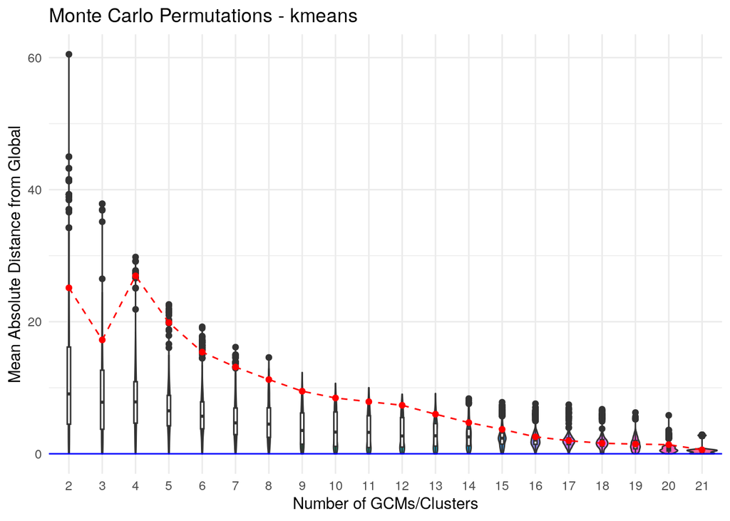

```
##
## $suggested_gcms
## $suggested_gcms$k2
##               1               2
##   "CNRM-ESM2-1" "CanESM5-CanOE"
##
## $suggested_gcms$k3
##               1               2               3
##   "CNRM-ESM2-1"    "MRI-ESM2-0" "CanESM5-CanOE"
##
## $suggested_gcms$k4
##               1               2               3               4
##    "MRI-ESM2-0" "MPI-ESM1-2-HR"   "CNRM-ESM2-1" "CanESM5-CanOE"
##
## $suggested_gcms$k5
##               1               2               3               4               5
## "CanESM5-CanOE"    "CNRM-CM6-1" "MPI-ESM1-2-HR"    "MRI-ESM2-0"   "UKESM1-0-LL"
##
## $suggested_gcms$k6
##               1               2               3               4               5
## "EC-Earth3-Veg"     "INM-CM4-8" "CanESM5-CanOE"   "UKESM1-0-LL"    "MRI-ESM2-0"
##               6
## "MPI-ESM1-2-HR"
##
## $suggested_gcms$k7
##               1               2               3               4               5
##    "MRI-ESM2-0" "MPI-ESM1-2-HR" "EC-Earth3-Veg"   "FIO-ESM-2-0" "CanESM5-CanOE"
##               6               7
##     "INM-CM4-8"   "UKESM1-0-LL"
##
## $suggested_gcms$k8
##               1               2               3               4               5
##   "GISS-E2-1-G"   "UKESM1-0-LL" "EC-Earth3-Veg" "CanESM5-CanOE"     "INM-CM4-8"
##               6               7               8
##    "MIROC-ES2L" "MPI-ESM1-2-HR"   "FIO-ESM-2-0"
##
## $suggested_gcms$k9
##               1               2               3               4               5
##   "CNRM-ESM2-1"   "FIO-ESM-2-0"    "MIROC-ES2L"   "GISS-E2-1-G" "CanESM5-CanOE"
##               6               7               8               9
```

[output cut: 104 more lines]

```
##       "MIROC-ES2L"    "ACCESS-ESM1-5"        "INM-CM4-8"  "HadGEM3-GC31-LL"
##
## $suggested_gcms$k21
##                  1                  2                  3                  4
##           "MIROC6"    "CNRM-CM6-1-HR"      "GISS-E2-1-H"       "ACCESS-CM2"
##                  5                  6                  7                  8
##  "HadGEM3-GC31-LL" "EC-Earth3-Veg-LR"    "MPI-ESM1-2-LR"     "IPSL-CM6A-LR"
##                  9                 10                 11                 12
##      "CNRM-ESM2-1"        "CMCC-ESM2"       "MIROC-ES2L"    "MPI-ESM1-2-HR"
##                 13                 14                 15                 16
##      "FIO-ESM-2-0"       "MRI-ESM2-0"    "ACCESS-ESM1-5"    "CanESM5-CanOE"
##                 17                 18                 19                 20
##        "INM-CM5-0"      "GISS-E2-1-G"    "EC-Earth3-Veg"       "CNRM-CM6-1"
##                 21
##        "INM-CM4-8"
```

```r
tictoc::tic("K-means Clustering 500")
mc_kmeans_500 <- montecarlo_gcms(s10,
                             var_names = c("bio1", "bio12"),
                             study_area = buffer500,
                             scale = TRUE,
                             perm = 10000,
                             dist_method = "euclidean",
                             clustering_method = "kmeans")
mc_kmeans_500
```

```r
kmeans_500 <- mc_kmeans_500$suggested_gcms$k3
tictoc::toc()
```

```
## K-means Clustering 500: 23.864 sec elapsed
```

### Closestdist selection

```r
tictoc::tic("Closestdist 50")
mc_closestdist_50 <- closestdist_gcms(s10,
                             var_names = c("bio1", "bio12"),
                             study_area = buffer50,
                             method = "euclidean")
```

```
## CRS from s and study_area are not identical. Reprojecting study area.
```

```r
mc_closestdist_50
```

```
## $suggested_gcms
## [1] "CMCC-ESM2"     "UKESM1-0-LL"   "IPSL-CM6A-LR"  "EC-Earth3-Veg"
##
## $best_mean_diff
## [1] 0.0002753937
##
## $global_mean
## [1] 21.36352
```

```r
closestdist_50 <- mc_closestdist_50$suggested_gcms
tictoc::toc()
```

```
## Closestdist 50: 1.714 sec elapsed
```

```r
tictoc::tic("Closestdist 100")
mc_closestdist_100 <- closestdist_gcms(s10,
                             var_names = c("bio1", "bio12"),
                             study_area = buffer100,
                             method = "euclidean")
```

```
## CRS from s and study_area are not identical. Reprojecting study area.
```

```r
mc_closestdist_100
```

```
## $suggested_gcms
## [1] "MIROC-ES2L"    "MPI-ESM1-2-HR" "MIROC6"        "MRI-ESM2-0"
##
## $best_mean_diff
## [1] 0.0003074422
##
## $global_mean
## [1] 24.97621
```

```r
closestdist_100 <- mc_closestdist_100$suggested_gcms
tictoc::toc()
```

```
## Closestdist 100: 1.789 sec elapsed
```

```r
tictoc::tic("Closestdist 150")
mc_closestdist_150 <- closestdist_gcms(s10,
                             var_names = c("bio1", "bio12"),
                             study_area = buffer150,
                             method = "euclidean")
```

```
## CRS from s and study_area are not identical. Reprojecting study area.
```

```r
mc_closestdist_150
```

```
## $suggested_gcms
## [1] "CanESM5-CanOE" "GISS-E2-1-G"   "INM-CM4-8"     "IPSL-CM6A-LR"
## [5] "MPI-ESM1-2-LR" "CNRM-CM6-1"    "MIROC-ES2L"    "CNRM-CM6-1-HR"
##
## $best_mean_diff
## [1] 0.0002528288
##
## $global_mean
## [1] 27.75368
```

```r
closestdist_150 <- mc_closestdist_150$suggested_gcms
tictoc::toc()
```

```
## Closestdist 150: 1.853 sec elapsed
```

```r
tictoc::tic("Closestdist 200")
mc_closestdist_200 <- closestdist_gcms(s10,
                             var_names = c("bio1", "bio12"),
                             study_area = buffer200,
                             method = "euclidean")
```

```
## CRS from s and study_area are not identical. Reprojecting study area.
```

```r
mc_closestdist_200
```

```
## $suggested_gcms
## [1] "CMCC-ESM2"     "MPI-ESM1-2-HR" "FIO-ESM-2-0"   "ACCESS-CM2"
## [5] "GISS-E2-1-G"   "INM-CM5-0"
##
## $best_mean_diff
## [1] 0.0005333435
##
## $global_mean
## [1] 30.15712
```

```r
closestdist_200 <- mc_closestdist_200$suggested_gcms
tictoc::toc()
```

```
## Closestdist 200: 1.965 sec elapsed
```

```r
tictoc::tic("Closestdist 250")
mc_closestdist_250 <- closestdist_gcms(s10,
                             var_names = c("bio1", "bio12"),
                             study_area = buffer250,
                             method = "euclidean")
```

```
## CRS from s and study_area are not identical. Reprojecting study area.
```

```r
mc_closestdist_250
```

```
## $suggested_gcms
## [1] "MIROC6"           "MRI-ESM2-0"       "IPSL-CM6A-LR"     "ACCESS-CM2"
## [5] "EC-Earth3-Veg-LR"
##
## $best_mean_diff
## [1] 0.0001436473
##
## $global_mean
## [1] 32.34868
```

```r
closestdist_250 <- mc_closestdist_250$suggested_gcms
tictoc::toc()
```

```
## Closestdist 250: 2.007 sec elapsed
```

```r
tictoc::tic("Closestdist 300")
mc_closestdist_300 <- closestdist_gcms(s10,
                             var_names = c("bio1", "bio12"),
                             study_area = buffer300,
                             method = "euclidean")
```

```
## CRS from s and study_area are not identical. Reprojecting study area.
```

```r
mc_closestdist_300
```

```
## $suggested_gcms
## [1] "EC-Earth3-Veg-LR" "GISS-E2-1-G"      "MPI-ESM1-2-LR"
##
## $best_mean_diff
## [1] 0.0002942981
##
## $global_mean
## [1] 34.12026
```

```r
closestdist_300 <- mc_closestdist_300$suggested_gcms
tictoc::toc()
```

```
## Closestdist 300: 2.055 sec elapsed
```

```r
tictoc::tic("Closestdist 350")
mc_closestdist_350 <- closestdist_gcms(s10,
                             var_names = c("bio1", "bio12"),
                             study_area = buffer350,
                             method = "euclidean")
```

```
## CRS from s and study_area are not identical. Reprojecting study area.
```

```r
mc_closestdist_350
```

```
## $suggested_gcms
## [1] "INM-CM5-0"    "MIROC-ES2L"   "ACCESS-CM2"   "IPSL-CM6A-LR" "GISS-E2-1-G"
##
## $best_mean_diff
## [1] 0.0005980465
##
## $global_mean
## [1] 35.61079
```

```r
closestdist_350 <- mc_closestdist_350$suggested_gcms
tictoc::toc()
```

```
## Closestdist 350: 2.188 sec elapsed
```

```r
tictoc::tic("Closestdist 400")
mc_closestdist_400 <- closestdist_gcms(s10,
                             var_names = c("bio1", "bio12"),
                             study_area = buffer400,
                             method = "euclidean")
```

```
## CRS from s and study_area are not identical. Reprojecting study area.
```

```r
mc_closestdist_400
```

```
## $suggested_gcms
## [1] "GISS-E2-1-G"      "IPSL-CM6A-LR"     "INM-CM5-0"        "CNRM-CM6-1"
## [5] "CMCC-ESM2"        "EC-Earth3-Veg-LR" "FIO-ESM-2-0"
##
## $best_mean_diff
## [1] 0.0003351331
##
## $global_mean
## [1] 36.82629
```

```r
closestdist_400 <- mc_closestdist_400$suggested_gcms
tictoc::toc()
```

```
## Closestdist 400: 2.235 sec elapsed
```

```r
tictoc::tic("Closestdist 450")
mc_closestdist_450 <- closestdist_gcms(s10,
                             var_names = c("bio1", "bio12"),
                             study_area = buffer450,
                             method = "euclidean")
```

```
## CRS from s and study_area are not identical. Reprojecting study area.
```

```r
mc_closestdist_450
```

```
## $suggested_gcms
## [1] "ACCESS-CM2"      "MPI-ESM1-2-HR"   "FIO-ESM-2-0"     "HadGEM3-GC31-LL"
## [5] "GISS-E2-1-G"
##
## $best_mean_diff
## [1] 0.0007142785
##
## $global_mean
## [1] 37.90422
```

```r
closestdist_450 <- mc_closestdist_450$suggested_gcms
tictoc::toc()
```

```
## Closestdist 450: 2.297 sec elapsed
```

```r
tictoc::tic("Closestdist 500")
mc_closestdist_500 <- closestdist_gcms(s10,
                             var_names = c("bio1", "bio12"),
                             study_area = buffer500,
                             method = "euclidean")
```

```
## CRS from s and study_area are not identical. Reprojecting study area.
```

```r
mc_closestdist_500
```

```
## $suggested_gcms
## [1] "CNRM-CM6-1"    "MPI-ESM1-2-HR" "MPI-ESM1-2-LR" "MIROC-ES2L"
## [5] "MIROC6"        "INM-CM5-0"
##
## $best_mean_diff
## [1] 0.0008346833
##
## $global_mean
## [1] 38.9711
```

```r
closestdist_500 <- mc_closestdist_500$suggested_gcms
tictoc::toc()
```

```
## Closestdist 500: 2.424 sec elapsed
```

### Closestdist selection

```r
tictoc::tic("Closestdist3 50")
mc_closestdist3_50 <- closestdist_gcms(s10,
                             var_names = c("bio1", "bio12"),
                             study_area = buffer50,
                             method = "euclidean",
                             k = 3)
```

```
## CRS from s and study_area are not identical. Reprojecting study area.
```

```r
mc_closestdist3_50
```

```
## $suggested_gcms
## [1] "ACCESS-CM2"    "EC-Earth3-Veg" "GISS-E2-1-H"
##
## $best_mean_diff
## [1] 0.005064835
##
## $global_mean
## [1] 21.36352
```

```r
closestdist3_50 <- mc_closestdist3_50$suggested_gcms
tictoc::toc()
```

```
## Closestdist3 50: 1.56 sec elapsed
```

```r
tictoc::tic("Closestdist3 100")
mc_closestdist3_100 <- closestdist_gcms(s10,
                             var_names = c("bio1", "bio12"),
                             study_area = buffer100,
                             method = "euclidean",
                             k = 3)
```

```
## CRS from s and study_area are not identical. Reprojecting study area.
```

```r
mc_closestdist3_100
```

```
## $suggested_gcms
## [1] "EC-Earth3-Veg-LR" "HadGEM3-GC31-LL"  "IPSL-CM6A-LR"
##
## $best_mean_diff
## [1] 0.007391347
##
## $global_mean
## [1] 24.97621
```

```r
closestdist3_100 <- mc_closestdist3_100$suggested_gcms
tictoc::toc()
```

```
## Closestdist3 100: 1.608 sec elapsed
```

```r
tictoc::tic("Closestdist3 150")
mc_closestdist3_150 <- closestdist_gcms(s10,
                             var_names = c("bio1", "bio12"),
                             study_area = buffer150,
                             method = "euclidean",
                             k = 3)
```

```
## CRS from s and study_area are not identical. Reprojecting study area.
```

```r
mc_closestdist3_150
```

```
## $suggested_gcms
## [1] "ACCESS-CM2"       "EC-Earth3-Veg-LR" "UKESM1-0-LL"
##
## $best_mean_diff
## [1] 0.0212794
##
## $global_mean
## [1] 27.75368
```

```r
closestdist3_150 <- mc_closestdist3_150$suggested_gcms
tictoc::toc()
```

```
## Closestdist3 150: 1.676 sec elapsed
```

```r
tictoc::tic("Closestdist3 200")
mc_closestdist3_200 <- closestdist_gcms(s10,
                             var_names = c("bio1", "bio12"),
                             study_area = buffer200,
                             method = "euclidean",
                             k = 3)
```

```
## CRS from s and study_area are not identical. Reprojecting study area.
```

```r
mc_closestdist3_200
```

```
## $suggested_gcms
## [1] "CNRM-CM6-1-HR" "FIO-ESM-2-0"   "INM-CM4-8"
##
## $best_mean_diff
## [1] 0.0008414798
##
## $global_mean
## [1] 30.15712
```

```r
closestdist3_200 <- mc_closestdist3_200$suggested_gcms
tictoc::toc()
```

```
## Closestdist3 200: 1.804 sec elapsed
```

```r
tictoc::tic("Closestdist3 250")
mc_closestdist3_250 <- closestdist_gcms(s10,
                             var_names = c("bio1", "bio12"),
                             study_area = buffer250,
                             method = "euclidean",
                             k = 3)
```

```
## CRS from s and study_area are not identical. Reprojecting study area.
```

```r
mc_closestdist3_250
```

```
## $suggested_gcms
## [1] "HadGEM3-GC31-LL" "INM-CM4-8"       "IPSL-CM6A-LR"
##
## $best_mean_diff
## [1] 0.01352089
##
## $global_mean
## [1] 32.34868
```

```r
closestdist3_250 <- mc_closestdist3_250$suggested_gcms
tictoc::toc()
```

```
## Closestdist3 250: 1.879 sec elapsed
```

```r
tictoc::tic("Closestdist3 300")
mc_closestdist3_300 <- closestdist_gcms(s10,
                             var_names = c("bio1", "bio12"),
                             study_area = buffer300,
                             method = "euclidean",
                             k = 3)
```

```
## CRS from s and study_area are not identical. Reprojecting study area.
```

```r
mc_closestdist3_300
```

```
## $suggested_gcms
## [1] "EC-Earth3-Veg-LR" "GISS-E2-1-G"      "MPI-ESM1-2-LR"
##
## $best_mean_diff
## [1] 0.0002942981
##
## $global_mean
## [1] 34.12026
```

```r
closestdist3_300 <- mc_closestdist3_300$suggested_gcms
tictoc::toc()
```

```
## Closestdist3 300: 1.924 sec elapsed
```

```r
tictoc::tic("Closestdist3 350")
mc_closestdist3_350 <- closestdist_gcms(s10,
                             var_names = c("bio1", "bio12"),
                             study_area = buffer350,
                             method = "euclidean",
                             k = 3)
```

```
## CRS from s and study_area are not identical. Reprojecting study area.
```

```r
mc_closestdist3_350
```

```
## $suggested_gcms
## [1] "EC-Earth3-Veg-LR" "FIO-ESM-2-0"      "HadGEM3-GC31-LL"
##
## $best_mean_diff
## [1] 0.01377996
##
## $global_mean
## [1] 35.61079
```

```r
closestdist3_350 <- mc_closestdist3_350$suggested_gcms
tictoc::toc()
```

```
## Closestdist3 350: 2.015 sec elapsed
```

```r
tictoc::tic("Closestdist3 400")
mc_closestdist3_400 <- closestdist_gcms(s10,
                             var_names = c("bio1", "bio12"),
                             study_area = buffer400,
                             method = "euclidean",
                             k = 3)
```

```
## CRS from s and study_area are not identical. Reprojecting study area.
```

```r
mc_closestdist3_400
```

```
## $suggested_gcms
## [1] "CMCC-ESM2"     "GISS-E2-1-H"   "MPI-ESM1-2-LR"
##
## $best_mean_diff
## [1] 0.0009890549
##
## $global_mean
## [1] 36.82629
```

```r
closestdist3_400 <- mc_closestdist3_400$suggested_gcms
tictoc::toc()
```

```
## Closestdist3 400: 2.119 sec elapsed
```

```r
tictoc::tic("Closestdist3 450")
mc_closestdist3_450 <- closestdist_gcms(s10,
                             var_names = c("bio1", "bio12"),
                             study_area = buffer450,
                             method = "euclidean",
                             k = 3)
```

```
## CRS from s and study_area are not identical. Reprojecting study area.
```

```r
mc_closestdist3_450
```

```
## $suggested_gcms
## [1] "FIO-ESM-2-0"   "INM-CM4-8"     "MPI-ESM1-2-LR"
##
## $best_mean_diff
## [1] 0.004906687
##
## $global_mean
## [1] 37.90422
```

```r
closestdist3_450 <- mc_closestdist3_450$suggested_gcms
tictoc::toc()
```

```
## Closestdist3 450: 2.167 sec elapsed
```

```r
tictoc::tic("Closestdist3 500")
mc_closestdist3_500 <- closestdist_gcms(s10,
                             var_names = c("bio1", "bio12"),
                             study_area = buffer500,
                             method = "euclidean",
                             k = 3)
```

```
## CRS from s and study_area are not identical. Reprojecting study area.
```

```r
mc_closestdist3_500
```

```
## $suggested_gcms
## [1] "ACCESS-ESM1-5" "CNRM-CM6-1"    "FIO-ESM-2-0"
##
## $best_mean_diff
## [1] 0.003674818
##
## $global_mean
## [1] 38.9711
```

```r
closestdist3_500 <- mc_closestdist3_500$suggested_gcms
tictoc::toc()
```

```
## Closestdist3 500: 2.242 sec elapsed
```